# The Ultimate Go Study Guide

## 소프트웨어 설계

### 조합

#### 그룹핑 형식

**상태에 의한 그룹핑**

이번 파트는 OOP 패턴의 유형계층에 대한 예시이다. 이는 Go 에서 자주 사용되는 방식은 아니다. Go 는 서브타이핑이라는 개념이 없기 때문이다. Go 에서 모든 타입은 고유하며 기본 타입, 파생된 타입이라는 개념은 존재하지 않는다. 즉, 이 패턴은 Go 프로그래밍에서는 좋은 설계 원칙이 아니다.

`Animal` 은 동물에 대한 기본 속성을 정의하고 있다.

```go
type Animal struct {
    Name     string
    IsMammal bool
}
```

`Speak` 는 동물들이 말하는 방식에 관한 일반적인 행동을 정의하고 있다. 스스로 말할 수 없는 동물 때문에 이는 무의미한 메서드일 수 있다. `Speak` 는 실제로 모든 동물이 가진 특성은 아니다.

```go
func (a *Animal) Speak() {
    fmt.Println("UGH!",
        "My name is", a.Name,
        ", it is", a.IsMammal,
        "I am a mammal")
}
```

`Dog` 는 `Animal` 과 관련된 모든것과 `PackFactor` 라는 `Dog` 만이 가진 속성을 정의하고 있다.

```go
type Dog struct {
    Animal
    PackFactor int
}
```

`Speak` 는 개가 말하는 방식을 의미한다.

```go
func (d *Dog) Speak() {
    fmt.Println("Woof!",
        "My name is", d.Name,
        ", it is", d.IsMammal,
        "I am a mammal with a pack factor of", d.PackFactor)
}
```

`Cat` 는 `Animal` 과 관련된 모든것과 `ClimbFactor` 라는 `Cat` 만이 가진 속성을 정의하고 있다.

```go
type Cat struct {
    Animal
    ClimbFactor int
}
```

`Speak` 는 고양이가 말하는 방식을 의미한다.

```go
func (c *Cat) Speak() {
    fmt.Println("Meow!",
        "My name is", c.Name,
        ", it is", c.IsMammal,
        "I am a mammal with a climb factor of", c.ClimbFactor)
}
```

여기까지는 괜찮을 지도 모른다. 하지만 이 코드는 컴파일되지 않는다. `Animals` 란 요소를 바탕으로 `Cat` 과 `Dog` 를 그루핑했기 때문이다. 즉, Go 는 서브타이핑 개념이 없는데도 불구하고 서브타이핑을 사용했다. Go 는 공통된 DNA(’구조체 내 공통된 필드’에 대한 비유)를 바탕으로 그룹핑하는 것을 권장하지 않는다. 누구인지에만 초점을 맞춘다면 그룹화하는데 큰 제한이 있기 때문에 공통된 DNA를 바탕으로 API 를 설계한다는 생각을 그만해야 한다. 서브타이핑은 다양성에 한계가 있다. 그룹화 가능하도록 서브셋을 작게 구성하면 그 형식과 관련된 것밖에 설계할 수 없지만, 행동에 초점을 맞추면 전체적인 형태로 넓혀서 설계할 수 있다.

`Animal` 부분을 초기화한 후 `Dog` 속성을 정의해서 `Dog` 를 생성한다.

```go
animals := []Animal{
    Dog{
        Animal: Animal{
            Name: "Fido",
            IsMammal: true,
        },
        PackFactor: 5,
    },
```

`Animal` 부분을 초기화한 후 `Cat` 속성을 정의해서 `Cat` 를 생성한다.

```go
    Cat{
        Animal: Animal{
            Name: "Milo",
            IsMammal: true,
        },
        ClimbFactor: 4,
    },
}
```

`Animal` 들이 말하도록 한다.

```go
    for _, animal := range animals {
        animal.Speak()
    }
}
```

위 방식이 냄새나는 코드인 이유:

- `Animal` 타입은 재사용 가능한 추상화된 계층을 제공한다.
- 이 프로그램은 `Animal` 타입으로 값을 만들거나 단독으로 사용할 필요가 전혀 없다.
- `Animal` 타입의 `Speak` 메서드 구현은 일반화이다.
- `Animal` 타입에서 정의한 `Speak` 메서드는 절대 호출되어지지 않는다.

**행동에 의한 그루핑**

이번 파트는 구성과 인터페이스를 활용한 예시이며 이는 Go 에서 사용되면 좋은 방식이다.

공통된 상태가 아닌 공통된 행동으로 그룹화하는 이 패턴은 Go 프로그램에서 좋은 설계 원칙이다. Go 의 뛰어난 특성중 하나는 미리 구성할 필요가 없다는 점이다. 컴파일러는 컴파일 타임에 인터페이스와 행동을 자동으로 식별한다. 이는 현재 또는 미래에 작성한 인터페이스와 호환될 수 있는 코드를 지금 작성할 수 있다는 의미이다. 또한 컴파일러가 즉석에서 행동을 식별하기 때문에 선언된 위치도 중요하지 않다. 대신 어떤 행동을 해야 하는지를 고려해야 한다.

`Speaker` 는 그룹이 일원이 되기 위해 따라야 할 공통된 행동을 정의하고 있다. `Speaker` 는 구체적인 타입에 대한 계약이다. `Animal` 타입은 제거한다.

```go
type Speaker interface {
    Speak()
}
```

`Dog` 는 `Dog` 가 필요한 모든 것을 정의하고 있다.

```go
type Dog struct {
    Name       string
    IsMammal   bool
    PackFactor int
}
```

`Speak` 는 개가 말하는 방식을 의미한다. 말하는 방식이 정의된 `Dog` 는 구체적인 타입인 `Speaker` 그룹의 일원이 된다.

```go
func (d Dog) Speak() {
    fmt.Println("Woof!",
        "My name is", d.Name,
        ", it is", d.IsMammal,
        "I am a mammal with a pack factor of", d.PackFactor)
}
```

`Cat`는 `Cat`이 필요한 모든 것을 정의하고 있다. 복사 붙여넣기를 하면 약간의 시간이 걸릴지도 모르지만, 대부분의 경우 디커플링은 코드 재사용보다 더 나은 방식이다.

```go
type Cat struct {
    Name        string
    IsMammal    bool
    ClimbFactor int
}
```

`Speak` 는 고양이가 말하는 방식을 의미한다. 말하는 방식이 정의된 `Cat` 는 구체적인 타입인 `Speaker` 그룹의 일원이 된다.

```go
func (c Cat) Speak() {
    fmt.Println("Meow!",
        "My name is", c.Name,
        ", it is", c.IsMammal,
        "I am a mammal with a climb factor of", c.ClimbFactor)
}
```

말하는 방식이 정의된 동물들을 생성해보자.

```go
func main() {
    speakers := []Speaker{
```

`Dog` 의 속성을 초기화해서 `Dog` 를 생성한다.

```go
        Dog{
            Name:       "Fido",
            IsMammal:   true,
            PackFactor: 5,
        },
```

`Cat` 의 속성을 초기화해서 `Cat` 을 생성한다.

```go
        Cat{
            Name:       "Milo",
            IsMammal:   true,
            ClimbFactor: 4,
        },
    }
```

`Speaker` 들이 말하도록 한다.

Have the Speakers speak.

```go
    for _, spkr := range speakers {
        spkr.Speak()
    }
```

```
Woof! My name is Fido , it is true I am a mammal with a pack factor of 5
Meow! My name is Milo , it is true I am a mammal with a climb factor of 4
```

타입 선언에 대한 지침:

- 새롭거나 유일한 것을 대표하는 타입을 선언한다. 가독성을 위해 별칭(alias)을 생성하지 않는다.
- 모든 타입의 값이 자체적으로 생성되거나 사용되었는지 확인한다.
- 상태가 아니라 행동을 위한 타입을 임베드 해야 한다. 행동에 대해 고려하지 않는다면 미래에 유지보수하기 어려운 설계가 될 수 있다.
- 특정 타입이 이미 있는 타입을 위한 별칭이거나 추상화하고 있다면 의문을 가져야 한다.
- 특정 타입이 유일한 목적이 공통 상태를 공유하는 것이라면 의문을 가져야 한다.

# 디커플링

## 구조체 구성 (Struct Composition)

프로토타이핑은 개념 증명(proof of concept) 작성이나 구체적 문제 해결 못지않게 중요하다. 디커플링과 리팩터링을 시작하기 전에 무엇을 바꿀 수 있는지, 어떤 변경을 해줘야 할지를 생각해야 한다. 리팩터링은 개발 주기의 일부가 되어야 한다.

다음과 같은 문제를 풀어보자. `Xenia` 라는 시스템은 데이테베이스를 가지고 있다. `Pillar`라는 또 다른 시스템은 프론트엔드를 가진 웹서버이며 `Xenia`를 이용한다. `Pillar` 역시 데이터베이스가 있다. `Xenia`의 데이터를 `Pillar`에 옮겨보자.

이 작업은 얼마나 걸릴까? 코드 한 부분이 완료 되었고, 다음 코드 구현을 해도 되는지를 어떻게 알 수 있을까? 기술 책임자라면, 작업에 시간을 “지나치게 낭비”한 것인지, “좀 더 시간을 들여야” 하는 지 어떻게 알 수 있을까?

완료 여부는 다음 두 가지를 확인하고 판단하자. 첫 번째는 테스트 커버리지이다. 100%면 더할 나위 없고 80% 이상을 커버하고 있다면 충분하다. 두 번째는 변경 가능 여부이다. 기술적 관점, 그리고 사업적 관점에서 무엇이 변할 수 있는지를 생각해보고, 리팩터링으로 대응이 가능하다면 된 것이다.

예를 들어, 이틀만에 작동하도록 구현을 완료하지만, 변경이 있을 거라는 것, 리팩터링을 통해 2주 정도 대응하면 된다는 것을 알고 있는 것이다. 한 번에 하나씩만 풀어나가면 된다. 모든 것을 완벽하게 할 필요는 없다. 코드와 테스트를 짠 다음에 리팩터링을 하는 것이다. 각 계층이 다음 계층을 위한 단단한 기초라는 것을 알고, 각자의 위에서 동작하는 API 계층을 만들자. [재방문]

세부적인 구현에 너무 신경을 쓸 필요는 없다. 중요한 것은 메커니즘(mechanics)이다. 우리는 올바르게 동작하도록 최적화하는 것이다. 성능은 언제든 개선할 수 있다.

```go
package main

import (
    "errors"
    "fmt"
    "io"
    "math/rand"
    "time"
)
```

우선, 타이머로 작동하는 소프트웨어가 필요하다. 소프트웨어는 `Xenia`에 접속해서, 데이터베이스를 읽고, 아직 옮기지 않은 모든 데이터를 찾아내고, 그것을 추출해야 한다.

```go
func init() {
    rand.Seed(time.Now().UnixNano())
}
```

`Data`는 우리가 복사하는 데이터 구조이다. 단순하게, 문자열 데이터라고 생각하면 된다.

```go
type Data struct {
    Line string
}
```

`Xenia`는 우리가 데이터를 추출 해야하는 시스템이다.

```go
type Xenia struct {
    Host    string
    Timeout time.Duration
}
```

`Pull`은 `Xenia`의 데이터를 추출하는 메서드이다. `func(*Xenia) Pull()(*Data, error)`와 같이 선언하여 데이터와 에러를 반환하도록 할 수도 있다. 하지만 이렇게 하면 호출을 할 때마다 할당 비용이 들 게 된다. 아래와 같이 메서드의 파라미터로 `d *Data`를 선언하면 `Data`의 타입과 크기를 미리 알 수 있다. 따라서 스택에 저장할 수 있게 된다.

```go
func (*Xenia) Pull(d *Data) error {
    switch rand.Intn(10) {
    case 1, 9:
        return io.EOF
    case 5:
        return errors.New("Error reading data from Xenia")
    default:
        d.Line = "Data"
        fmt.Println("In:", d.Line)
        return nil
    }
}
```

`Pillar`는 데이터를 저장할 시스템이다.

```go
type Pillar struct {
    Host    string
    Timeout time.Duration
}
```

`Store` 메서드로 `d *Data`를 `Piller`에 저장할 수 있다. 일관되도록 포인터 `*Pillar`를 사용하였다.

```go
func (*Pillar) Store(d *Data) error {
    fmt.Println("Out:", d.Line)
    return nil
}
```

`System`은 `Xenia`와 `Piller`를 하나의 시스템으로 결합한다. 우리는 `Xenia`와 `Piller`를 기반으로 한 API를 가지고 있다. 여기에 또 다른 API를 구축해 그것을 기반으로 활용하려고 한다. 한 가지 방법은 추출 하거나 저장할 수 있는 행동을 하는 타입을 갖는 것이다. 우리는 구성(composition)을 통해 그것을 할 수 있다. `System`은 `Xenia`와 `Piller`의 내장된 요소를 기반으로 한다. 그리고 내부 타입 승격(inner type promotion) 때문에 `System`에서는 추출과 저장하는 방법을 알고 있다.

```go
type System struct {
    Xenia
    Pillar
}
```

`pull`은 우리가 구축한 기반을 활용하여 `Xenia`로 부터 많은 양의 데이터를 추출할 수 있다.

이를 위해 `System`에 메서드를 추가할 필요는 없다. `System` 내부에 `System`이 관리할 상태(state)는 없다. 대신에, `System`이 무엇을 할 수 있는지를 이해하기만 하면 된다.

함수는 API를 만드는 좋은 방법이다. 함수가 대체로 메서드보다 읽기 쉽기 때문이다. 패키지 레벨에서 함수로 API 를 구현해 보는걸로 구현을 시작해보자.

함수를 작성할 때 모든 입력은 반드시 전달되어야 한다. 메서드를 사용할 때에, 메서드 시그니처(signature)만으로는 우리가 호출할 때에 사용하는 값이 어떤 레벨, 어떤 필드나 상태인지 알 수 없다.

```go
func pull(x *Xenia, data []Data) (int, error) {
```

데이터 슬라이스를 순회하면서 각각의 원소를 `Xenia`의 `Pull` 메서드에 전달하자.

```go
    for i := range data {
        if err := x.Pull(&data[i]); err != nil {
            return i, err
        }
    }

    return len(data), nil
}
```

`store`를 이용하여 많은 양의 데이터를 `Pillar`에 저장할 수 있다. 위의 기능과 유사하다. 효율적인지 의문이 들지도 모른다. 하지만 정확성(correctness)을 목표로 최적화 하고 있다. 성능(performance)은 그 다음 문제이다. 구현이 완료되면 테스트를 할 것이고, 속도가 충분히 빠르지 않다면, 복잡해지더라도 성능을 개선할 것이다.

```go
func store(p *Pillar, data []Data) (int, error) {
    for i := range data {
        if err := p.Store(&data[i]); err != nil {
            return i, err
        }
    }

    return len(data), nil
}
```

`Copy`를 이용하여 `System`의 데이터를 추출할 수 있다. 이제 `pull`과 `store` 함수를 호출하여 `Xenia`에서 `Piller`로 데이터를 전달할 수 있다.

```go
func Copy(sys *System, batch int) error {
    data := make([]Data, batch)

    for {
        i, err := pull(&sys.Xenia, data)
        if i > 0 {
            if _, err := store(&sys.Pillar, data[:i]); err != nil {
                return err
            }
        }

        if err != nil {
            return err
        }
    }
}
```

```go
func main() {
    sys := System {
        Xenia: Xenia {
            Host:    "localhost:8000",
            Timeout: time.Second,
        },
        Pillar: Pillar {
            Host:    "localhost:9000",
            Timeout: time.Second,
        },
    }

    if err := Copy(&sys, 3); err != io.EOF {
        fmt.Println(err)
    }
}
```

```
In: Data
In: Data
In: Data
Out: Data
Out: Data
Out: Data
In: Data
In: Data
Out: Data
Out: Data
```

## 인터페이스로 디커플링

API를 보면, API는 구체적인 구현에서 디커플링 할 필요가 있다. 이 디커플링은 초기화 까지 도달 해야 하고 제대로 하기위해선 초기화 코드만 변경하면 된다. 다른 모든것은 이러한 유형이 제공 할 행동에 따라 수행 할 수 있어야 한다.

`pull`은 구체화 된 것 이며, `Xenia`에서만 수행 한다. 그러나, 데이터를 추출 하는 `pull`을 디커플링 할 수 있다면 우리는 가장 높은 수준의 디커플링을 얻을 수 있다. 우리는 이미 효율적인 알고리즘을 가지고 있기 때문에, 다른 레벨에서 일반화를 추가 하거나 구체화에서 이미 했던 작업을 의미 없게 하면 안된다. `store`도 마찬가지 이다.

구체화에서 부터 올라오는것이 좋다. 이렇게 하면, 문제를 효율적으로 해결하고 기술 부채를 줄일 뿐만 아니라 계약들도 우리에게 오게 된다. 우리는 이미 데이터를 추출/저장 하는 계약이 무엇인지 알고 있다. 이미 그것을 검증했고 우리가 필요한 것이다.

이 2개의 함수를 디커플링하고 인터페이스 2개를 추가하자. `Puller`는 추출기능, `Storer` 는 저장기능을 한다.

`Xenia`는 이미 `Puller` 인터페이스를 구현했고, `Pillar`는 `Storer` 인터페이스를 구현 했다. 이제 `pull`/`store`에 들어가서 구체화로 부터 이 함수를 디커플링 해보자

`Xenial`와 `Pillar`를 넘나드는 것 대신에, 우리는 `Puller`와 `Storer` 사이를 넘나들 수 있다. 알고리즘은 변하지 않는다. 우리가 하고 있는 모든 것들은 인터페이스 값을 통해서 간접적으로 `pull`/`store`를 호출 하는 것이다.

```go
package main
import (
    "errors"
    "fmt"
    "io"
    "math/rand"
    "time"
)

func init() {
    rand.Seed(time.Now().UnixNano())
}
```

`Data`는 복사 할 데이터의 구조체이다.

```go
 type Data struct {
     Line string
}
```

`Puller` 는 데이터 추출 동작을 선언한다.

```go
type Puller interface {
    Pull(d *Data) error
}
```

`Storer` 는 데이터 저장 동작을 선언한다.

```go
type Storer interface {
    Store(d *Data) error
}
```

`Xenia`는 우리가 데이터를 빼내야 하는 시스템이다.

```go
type Xenia struct {
    Host    string
    Timeout time.Duration
}
```

`Pull`은 `Xenia`에서 데이터를 가져오는 방법을 알고 있다.

```go
func (*Xenia) Pull(d *Data) error {
    switch rand.Intn(10) {
    case 1, 9:
        return io.EOF
    case 5:
        return errors.New("Error reading data from Xenia")
    default:
        d.Line = "Data"
        fmt.Println("In:", d.Line)
        return nil
    }
}
```

`Pillar`는 우리가 데이터를 저장 해야 하는 시스템이다.

```go
 type Pillar struct {
     Host    string
     Timeout time.Duration
 }
```

`Store`은 `Pillar`에 데이터를 저장하는 방법을 알고 있다.

```go
func (*Pillar) Store(d *Data) error {
    fmt.Println("Out:", d.Line)
    return nil
}
```

`System`은 `Xenia`와 `Piller`를 하나의 시스템으로 결합한다.

```go
type System struct {
    Xenia
    Pillar
}
```

`pull`은 `Puller`로 부터 많은 양의 데이터를 추출하는 방법을 알고 있다.

```go
func pull(p Puller, data []Data) (int, error) {
    for i := range data {
        if err := p.Pull(&data[i]); err != nil {
            return i, err
        }
    }
    return len(data), nil
}
```

`store`은 `Storer`로 부터 많은 양의 데이터를 저장하는 방법을 알고 있다.

```go
func store(s Storer, data []Data) (int, error) {
    for i := range data {
        if err := s.Store(&data[i]); err != nil {
            return i, err
        }
    }
    return len(data), nil
}
```

`Copy`는 `System`에서 데이터를 추출하고 저장하는 방법을 알고 있다.

```go
func Copy(sys *System, batch int) error {
    data := make([]Data, batch)

    for {
        i, err := pull(&sys.Xenia, data)
        if i > 0 {
            if _, err := store(&sys.Pillar, data[:i]); err != nil {
                return err
            }
        }
        if err != nil {
            return err
        }
    }
}
```

```go
func main() {
    sys := System{
        Xenia: Xenia{
            Host:    "localhost:8000",
            Timeout: time.Second,
        },
        Pillar: Pillar{
            Host:    "localhost:9000",
            Timeout: time.Second,
        },
    }

    if err := Copy(&sys, 3); err != io.EOF {
        fmt.Println(err)
    }
}
```

```
In: Data
In: Data
In: Data
Out: Data
Out: Data
Out: Data
In: Data
In: Data
Out: Data
Out: Data
```

## 인터페이스 구성

인터페이스 구성을 사용하여 인터페이스를 추가하자. `PullStorer`에는 `Puller`와 `Storer`의 두 가지 동작이 있다. 추출과 저장을 모두 구현하는 구체적인 타입은 `PullStorer`이다. `System`이 `PullStorer`인 이유는 `Xenia`와 `Piller` 이 두 가지 타입이 내장되어 있기 때문이다. 이제 다른 코드는 변경할 필요없이 `Copy`에 들어가서 `PullStorer`로 시스템 포인터를 교체하면 된다.

`Copy`를 자세히 보면, 잠재적으로 우리를 혼란스럽게 할 수 있는 것이 있다. 우리는 `PullStorer` 인터페이스 값을 직접적으로 `Pull`과 `Store`에 전달하고 있다.

추출과 저장을 살펴보면, 그것들은 `PullStorer`가 필요하지 않다. 한 쪽은 `Puller`, 다른 한 쪽은 `Storer`만 있으면 된다. 왜 컴파일러는 이전에는 허용하지 않았던 다른 타입의 값 전달을 허용하는 것일까?

Go에는 암시적 인터페이스 변환이라는 기능이 있기 때문이다. 이것은 아래의 이유 때문에 가능하다:

- 모든 인터페이스 값이 동일한 모델(구현 세부 정보).
- 만약 타입의 내용이 명확하다면, 하나의 인터페이스 안에 존재하는 구체적인 타입은 다른 인터페이스에 대해 충분한 동작을 가진다.

  `PullStorer` 내부에 저장된 모든 구체적인 타입은 `Storer` 및 `Puller`도 구현해야 한다.

코드를 자세히 살펴보자.

주요 기능에서 우리는 `System` 타입의 값을 만들고 있다. 알고 있듯이, 우리의 `System` 타입 값은 두 가지 구체 타입인 `Xenia`와 `Piller`를 내장하고 있는데, 여기서 `Xenia`는 추출기능, `Filler`는 저장기능을 알고 있다. 내부 타입 승격(inner type promotion) 때문에 `System`은 본질적으로 추출하고 저장하는 방법을 알고 있다. 우리는 `System` 주소를 `Copy`에 전달하고 있다. 그 다음 `Copy`가 `PullStorer` 인터페이스를 생성한다. 첫 번째는 `System`의 포인터이고 두 번째는 원래 값을 가리킨다. 이 인터페이스는 이제 추출 및 저장하는 방법을 안다. 우리가 `ps`의 `pull`을 호출할 때, 우리는 `System`의 `pull`을 호출하고, 그것은 결국 `Xenia`의 `pull`을 호출한다.

여기 예기치 못한 것이있다: 암시적 인터페이스 변환

컴파일러가 `PullStorer` 내부에 저장된 모든 구체적인 타입도 `Puller`를 구현해야 한다는 것을 알고 있기 때문에 `pull` 인터페이스 값 `ps`를 전달할 수 있다. 우리는 결국 `Puller`라는 또 다른 인터페이스를 갖게 된다. 모든 인터페이스에 대해 메모리 모델이 동일하기 때문에, 우리는 이 두 가지를 복사하여 모두 동일한 인터페이스 타입을 공유한다. 이제 `Puller`의 `pull`을 호출할 때 `System`의 `pull`을 호출할 것이다.

`Storer`와 유사

모두 인터페이스 값에 대한 가치 의미와 공유하기 위한 포인터 의미.

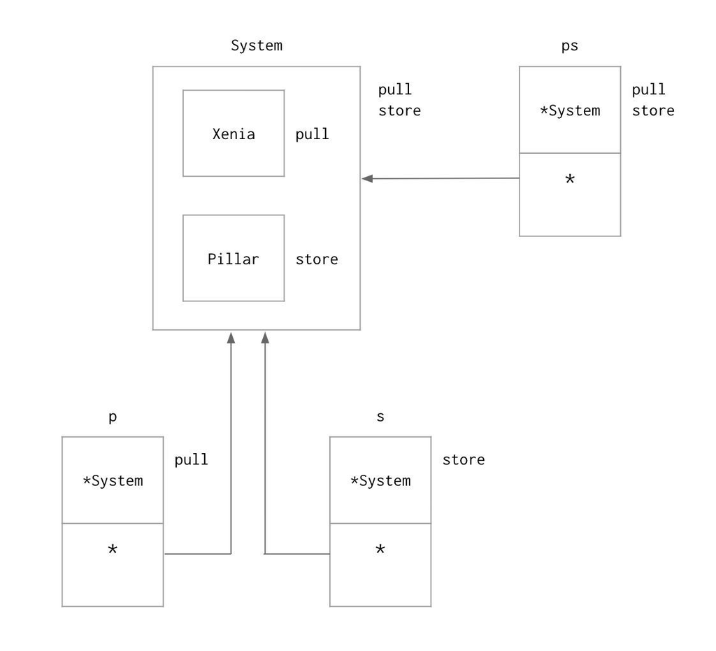

```go
package main

import (
    "errors"
    "fmt"
    "io"
    "math/rand"
    "time"
)

func init() {
    rand.Seed(time.Now().UnixNano())
}
```

`Data`는 복사 할 데이터의 구조체이다.

```go
type Data struct {
    Line string
}
```

`Puller` 는 데이터 추출 동작을 선언한다.

```go
type Puller interface {
    Pull(d *Data) error
}
```

`Storer` 는 데이터 저장 동작을 선언한다.

```go
type Storer interface {
    Store(d *Data) error
}
```

`PullStore`는 추출 및 저장에 대한 동작을 선언한다.

```go
type PullStorer interface {
    Puller
    Storer
}
```

`Xenia`는 우리가 데이터를 빼내야 하는 시스템이다.

```go
type Xenia struct {
    Host    string
    Timeout time.Duration
}
```

`Pull`은 `Xenia`에서 데이터를 가져오는 방법을 알고 있다.

```go
func (*Xenia) Pull(d *Data) error {
    switch rand.Intn(10) {
        case 1, 9:
            return io.EOF
        case 5:
            return errors.New("Error reading data from Xenia")
        default:
            d.Line = "Data"
            fmt.Println("In:", d.Line)
            return nil
    }
}
```

`Pillar`는 우리가 데이터를 저장 해야 하는 시스템이다.

```go
type Pillar struct {
    Host string
    Timeout time.Duration
}
```

`Store`은 `Pillar`에 데이터를 저장하는 방법을 알고 있다.

```go
func (*Pillar) Store(d *Data) error {
    fmt.Println("Out:", d.Line)
    return nil
}
```

`System`은 `Xenia`와 `Piller`를 하나의 시스템으로 결합한다.

```go
type System struct {
    Xenia
    Pillar
}
```

`pull`은 `Puller`로 부터 많은 양의 데이터를 추출하는 방법을 알고 있다.

```go
func pull(p Puller, data []Data) (int, error) {
    for i := range data {
        if err := p.Pull(&data[i]); err != nil {
            return i, err
        }
    }

    return len(data), nil
}
```

`store`은 `Storer`로 부터 많은 양의 데이터를 저장하는 방법을 알고 있다.

```go
func store(s Storer, data []Data) (int, error) {
    for i := range data {
        if err := s.Store(&data[i]); err != nil {
            return i, err
        }
    }

    return len(data), nil
}
```

`Copy`는 `System`에서 데이터를 추출하고 저장하는 방법을 알고 있다.

```go
func Copy(ps PullStorer, batch int) error {
    data := make([]Data, batch)

    for {
        i, err := pull(ps, data)
        if i > 0 {
            if _, err := store(ps, data[:i]); err != nil {
                return err
            }
        }

        if err != nil {
            return err
        }
    }
}
```

```go
func main() {
    sys := System {
        Xenia: Xenia {
            Host:    "localhost:8000",
            Timeout: time.Second,
        },
        Pillar: Pillar {
            Host:    "localhost:9000",
            Timeout: time.Second,
        },
    }

    if err := Copy(&sys, 3); err != io.EOF {
        fmt.Println(err)
    }
}
```

```
In: Data
In: Data
In: Data
Out: Data
Out: Data
Out: Data
In: Data
In: Data
Out: Data
Out: Data
```

## 인터페이스 구성을 사용한 디커플링

우리는 구체타입 `System`을 바꾼다. 두 가지 구체타입 `Xenia`와 `Pillar`를 사용하는 대신 인터페이스 `Puller`와 `Storer`를 사용한다. 구체적인 동작을 할 수 있는 구체타입 `System`은 이제 2가지 인터페이스 임베딩을 기반으로 한다. 이것은 공통의 DNA가 아닌, 우리가 필요로 하는 능력과 동작을 제공하는 데이터를 기반으로 어떤 데이터든 주입할 수 있다는 것을 의미한다.

이제 코드가 완전히 분리되었다. 왜냐하면 `Puller`를 구현하는 모든 값들은 `System`(`Storer`와 동일)에 저장할 수 있기 때문이다. 여러 개의 `System`을 만들 수 있으며 데이터는 `Copy`로 전달할 수 있다.

여기서 메소드는 필요없다. 단지 데이터를 받는 하나의 함수가 필요하며, 그것의 동작은 입력한 데이터에 따라 달라진다.

이제 `System`은 더 이상 `Xenia`와 `Pillar`를 기반으로 하지 않는다. `Xenia`를 저장하는 인터페이스와 `Pillar`를 저장하는 인터페이스 두 개를 기반으로 한다. 우리는 추가적인 디커플링 층을 갖게 되었다.

시스템이 바뀌어도 큰 문제가 되지 않는다. 프로그램 시작에 필요한 대로 시스템을 교체만 하면 된다.

우리는 이 문제를 해결 하고 제품에 반영한다. 우리가 했던 모든 리팩터링은 다음 리팩터링을 하기전에 제품에 반영하였다. 우리는 계속해서 기술부채를 최소화하고 있다.

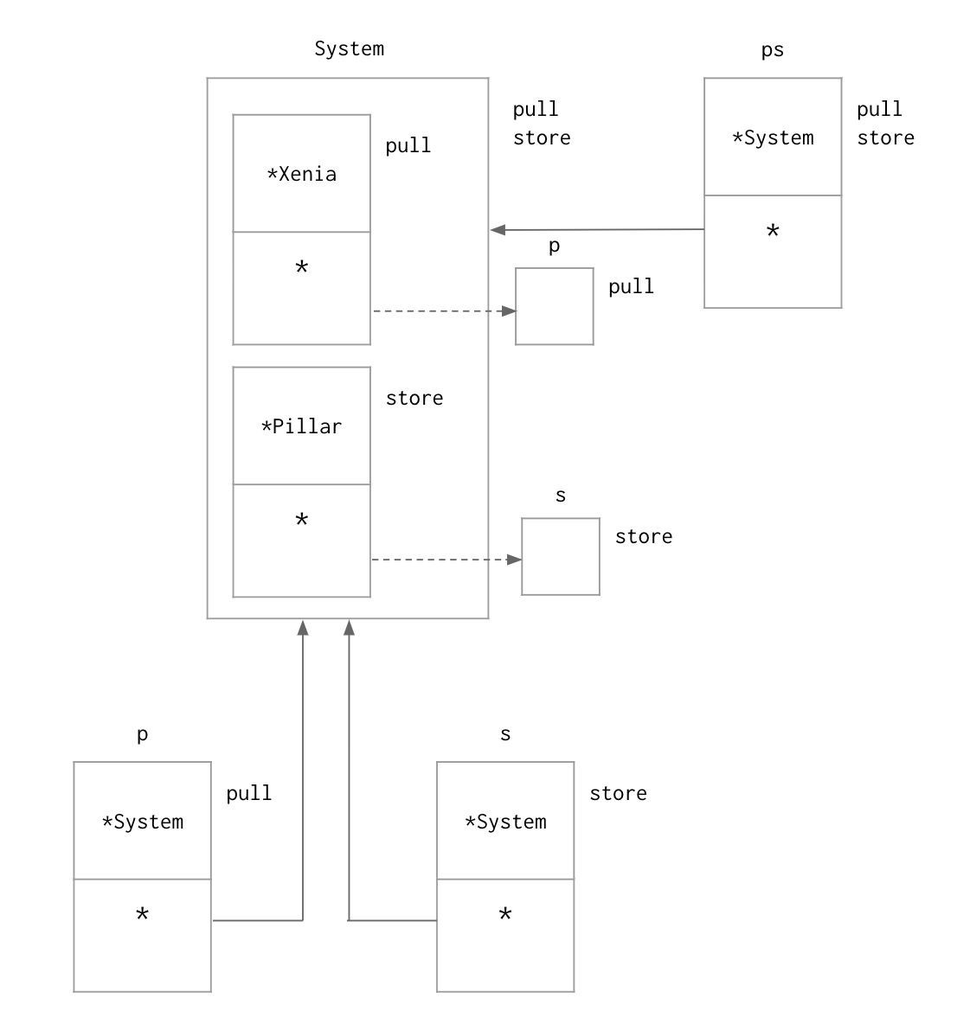

```go
package main
import (
    "errors"
    "fmt"
    "io"
    "math/rand"
    "time"
)

func init() {
    rand.Seed(time.Now().UnixNano())
}
```

`Data`는 복사 할 데이터의 구조체이다.

```go
type Data struct {
    Line string
}
```

`Puller` 는 데이터 추출 동작을 선언한다.

```go
type Puller interface {
    Pull(d *Data) error
}
```

`Storer` 는 데이터 저장 동작을 선언한다.

```go
type Storer interface {
    Store(d *Data) error
}
```

`PullStore`는 추출 및 저장에 대한 동작을 선언한다.

```go
type PullStorer interface {
    Puller
    Storer
}
```

`Xenia`는 우리가 데이터를 빼내야 하는 시스템이다.

```go
type Xenia struct {
    Host    string
    Timeout time.Duration
}
```

`Pull`은 `Xenia`에서 데이터를 가져오는 방법을 알고 있다.

```go
func (*Xenia) Pull(d *Data) error {
    switch rand.Intn(10) {
        case 1, 9:
            return io.EOF
        case 5:
            return errors.New("Error reading data from Xenia")
        default:
            d.Line = "Data"
            fmt.Println("In:", d.Line)
            return nil
    }
}
```

`Pillar`는 우리가 데이터를 저장 해야 하는 시스템이다.

```go
type Pillar struct {
    Host    string
    Timeout time.Duration
}
```

`Store`은 `Pillar`에 데이터를 저장하는 방법을 알고 있다.

```go
func (*Pillar) Store(d *Data) error {
    fmt.Println("Out:", d.Line)
    return nil
}
```

`System`은 `Pullers`와 `Stores`를 하나의 시스템으로 결합한다.

```go
type System struct {
    Puller
    Storer
}
```

`pull`은 `Puller`로 부터 많은 양의 데이터를 추출하는 방법을 알고 있다.

```go
func pull(p Puller, data []Data) (int, error) {
    for i := range data {
        if err := p.Pull(&data[i]); err != nil {
            return i, err
        }
    }

    return len(data), nil
}
```

`store`은 `Storer`로 부터 많은 양의 데이터를 저장하는 방법을 알고 있다.

```go
func store(s Storer, data []Data) (int, error) {
    for i := range data {
        if err := s.Store(&data[i]); err != nil {
            return i, err
        }
    }

    return len(data), nil
}
```

`Copy`는 `System`에서 데이터를 추출하고 저장하는 방법을 알고 있다.

```go
func Copy(ps PullStorer, batch int) error {
    data := make([]Data, batch)

    for {
        i, err := pull(ps, data)
        if i > 0 {
            if _, err := store(ps, data[:i]); err != nil {
                return err
            }
        }

        if err != nil {
            return err
        }
    }
}

func main() {
    sys := System {
        Puller: &Xenia {
            Host: "localhost:8000",
            Timeout: time.Second,
        },
        Storer: &Pillar {
            Host: "localhost:9000",
            Timeout: time.Second,
        },
    }

    if err := Copy(&sys, 3); err != io.EOF {
        fmt.Println(err)
    }
}
```

```
In: Data
In: Data
In: Data
Out: Data
Out: Data
Out: Data
In: Data
In: Data
Out: Data
Out: Data
```

# 89-101

## 변환(Conversion)

### 인터페이스 변환

`Mover`는 움직이는 것을 나타내기 위해 다음과 같이 정의합니다.

```go
type Mover interface {
    Move()
}
```

`Locker`는 잠그고(locking) 해제(unlocking)할 수 있는 것을 나타냅니다.

```go
type Locker interface {
    Lock()
    Unlock()
}
```

`MoveLocker`는 움직이거나 잠글 수 있는 것을 나타냅니다.

```go
type MoveLocker interface {
    Mover
    Locker
}
```

구체적인 예시를 위해 `bike`라는 타입을 정의합니다.

```go
type bike struct {}
```

`Move`는 `bike`를 움직입니다.

```go
func (bike) Move() {
    fmt.Println("Moving the bike")
}
```

`Lock`은 `bike`가 움직이지 못하게 합니다.

```go
func (bike) Lock() {
    fmt.Println("Locking the bike")
}
```

`Unlock`을 하면 `bike`는 다시 움직일 수 있습니다.

```go
func (bike) Unlock() {
    fmt.Println("Unlocking the bike")
}

func main() {
```

`MoverLocker`와 `Mover` 인터페이스 타입의 변수를 선언합니다. zero value로 초기화 됩니다.

```go
    var ml MoveLocker
    var m Mover
```

`bike` 값을 생성하여 `MoveLocker` 인터페이스 타입 변수에 대입합니다.

```go
    ml = bike{}
```

`MoveLocker` 인터페이스 타입 변수는 `Mover` 인터페이스 타입 변수로 변환할 수 있습니다. 둘 모두 `move`라는 메쏘드를 정의했기 때문입니다.

```go
    m = ml
```

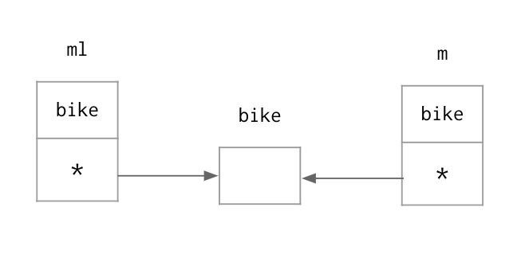

`MoveLocker`에서 `Mover`로 암묵적 변환

하지만, 아래와 같이 반대로는 불가능합니다.

```go
    ml = m
```

컴파일을 하면 다음과 같은 에러가 발생합니다.

```
cannot use m (type Mover) as type MoveLocker in assignment:
Mover does not implement MoveLocker (missing Lock method).
```

### 타입 단언(Type assertion)

인터페이스 타입 `Mover`는 `lock`과 `unlock` 메서드를 정의하고 있지 않다. 따라서, 컴파일러는 인터페이스 `Mover` 타입의 변수를 `MoveLocker` 타입의 변수로 암묵적으로 변환할 수 없다. `Mover` 인터페이스 변수의 실제 값이 `MoveLocker` 인터페이스를 구현한 `bike` 타입의 값이라 해도 변환하지 않는다. 런타임때 타입 단언을 사용하여 명시적으로 변환할 수는 있다.

아래와 같이 `Mover` 인터페이스의 값을 타입 단언을 사용해 `bike` 타입의 값으로 변환 후 복사한다. 복사된 값을 `MoveLocker` 인터페이스 변수에 배정한다. 아래 코드가 타입 단언의 문법이다. 인터페이스 값에 `인터페이스값.(bike)`처럼 점(.)에 파라미터로 `bike` 값을 전달한다. `m` 이 `nil`이 아닌 `bike` 타입의 값이 들어있을 경우, 포인터가 아닌 값을 넘겨받았기(value semantics) 때문에 `m`을 복사한 값을 얻게 된다. 그렇지 않을 경우 `panic`이 발생하게 된다. 아래 예시에서 `b`는 `bike`의 복사된 값을 가지고 있다.

```go
    b := m.(bike)
```

타입 단언의 성공 여부를 나타내는 `boolean` 값을 받아 `panic`을 예방 할 수도 있다.

```go
    b, ok := m.(bike)
    fmt.Println("Does m has value of bike?:", ok)

    ml = b
```

```
Does m has value of bike?: true
```

타입 단언의 문법을 통해 인터페이스 변수에 실제 저장된 값의 타입이 무엇인지 알 수 있다. 캐스팅을 사용하는 다른 언어에 비해 가독성 관점에서 큰 장점이라고 할 수 있다.

### 런타임 타입 단언

```go
package main
import (
    "fmt"
    "math/rand"
    "time"
)
```

`car`는 무엇가 운전할 수 있는 것을 의미한다.

```go
type car struct{}
```

`String`은 `fmt.Stringer` 인터페이스를 구현한다.

```go
func (car) String() string {
    return "Vroom!"
}
```

`cloud`는 정보를 저장해 둘 장소를 의미한다.

```go
type cloud struct{}
```

`String`은 마찬가지로 `fmt.Stringer` 인터페이스를 구현한다.

```go
func (cloud) String() string {
    return "Big Data!"
}
```

랜덤 함수에 사용될 `Seed`값을 정한다.

```go
func main() {
    rand.Seed(time.Now().UnixNano())
```

`Stringer` 인터페이스를 가지는 슬라이스를 생성한다.

```go
    mvs := []fmt.Stringer{
        car{},
        cloud{},
    }
```

아래와 같은 코드를 10번 반복해보자.

```go
    for i := 0; i < 10; i++ {
        rn := rand.Intn(2)
```

아래와 같이 랜덤으로 생성된 숫자를 통해 `cloud`에 대한 타입 단언을 실행한다. 아래 예시는 타입 단언이 컴파일 때가 아닌 런타임때 실행된다는 것을 알 수 있다.

```go
        if v, ok := mvs[rn].(cloud); ok {
            fmt.Println("Got Lucky:", v)
            continue
        }
```

`x`라는 변수가 있으면 `x.(T)`를 통해 `T` 타입으로 단언 될 수 있는지 확인해줘야 한다. 아니면 무결성 등의 이유로 `panic`하길 원할 경우라면 `ok` 변수를 사용하지 않을 것이다. `panic`으로부터 회복할 수 없으면 프로그램은 종료될 것이고 재시작해야 한다.

프로그램이 종료된다는 의미는 스택 트레이스가 출력되는 `log.Fatal`, `os.exit` 혹은 `panic` 함수를 호출했다는 것이다. 타입 단언을 사용할 때는, 요청하는 타입의 값이 들어있지 않아도 괜찮은지 확인해야 한다.

타입 단언을 사용해 구체적인 타입의 값을 꺼낼 경우, 주의해서 사용한다. 디커플링의 레벨을 유지하기 위해 인터페이스를 사용했는데 타입 단언을 사용해 다시 이전으로 돌아가기 때문이다.

구체적인 타입을 사용할 경우 연관 있는 많은 코드를 동시에 리팩토링을 해야 될 수도 있다는 것을 알아야 한다. 반대로 인터페이스를 사용할 경우 내부 구현이 변해도 그로 인해 발생하는 변경점들은 최소화 할 수 있다.

```go
        fmt.Println("Got Unlucky")
    }
}
```

```
Got Unlucky
Got Unlucky
Got Lucky: Big Data!
Got Unlucky
Got Lucky: Big Data!
Got Lucky: Big Data!
Got Unlucky
Got Lucky: Big Data!
Got Unlucky
Got Unlucky
```

## 인터페이스 오염(Interface Pollution)

소프트웨어를 설계할 때, 구체적인 타입이 아닌 인터페이스부터 설계한다. 인터페이스를 사용하는 이유는 무엇일까?

**미신 #1:** 인터페이스를 사용해야하기 때문에 인터페이스를 사용하고 있다.

답: 아니오. 인터페이스를 사용할 필요가 없다. 합리적이고 실용적일 때 인터페이스를 사용해야 한다.

인터페이스를 사용하는 데는 비용이 든다. 구체적인 타입을 인터페이스 타입으로 사용 될때 잠재적 할당 비용과 추상화 비용이 그것이다. 디커플링에 그만한 비용의 가치가 없다면 인터페이스를 사용해서는 안된다.

**미신 #2:** 코드를 테스트 하기 위해 인터페이스를 사용해야 한다.

답: 아니오. 테스트가 아니라 개발자를 우선하여 애플리케이션에 사용할 수 있는 API를 설계해야한다.

다음은 필요하지 않은 인터페이스를 사용하여 인터페이스 오염을 생성하는 예이다.

`Server`는 TCP 서버에 대한 계약을 정의한다. 이것은 약간의 코드 악취에 해당하는데 이것은 사용자에게 노출 될 API이고 하나의 인터페이스에 넣기에 많은 동작이다.

```go
type Server interface {
    Start() error
    Stop() error
    Wait() error
}
```

`server`는 `Server` 인터페이스를 구현한다. 이름이 일치하지만 꼭 나쁘다고 할 수 는 없다.

```go
type server struct {
    host string
}
```

`NewServer`는 인터페이스 `Server` 타입을 리턴하는 팩토리 함수이다. 인터페이스를 반환함으로 코드스멜로 볼 수 있다.

함수나 인터페이스가 꼭 인터페이스 값을 반환하지 못하는 건 아니다. 반환해도 된다. 하지만, 보통은 주의해야 한다. 구체적인 타입이 동작을 가지고 있는 데이터이며 인터페이스는 그런 데이터를 받는 인풋으로써 사용되어야 한다.

코드 악취 - Export 되지 않은 타입 포인터를 인터페이스에 저장함

```go
func NewServer(host string) Server {
    return &server{host}
}
```

`Start` 는 서버를 시작해 요청을 받기 시작한다. 여기서는 실제 구현이 되있다고 가정한다.

```go
func (s *server) Start() error {
    return nil
}
```

`Stop`은 서버를 멈춥니다.

```go
func (s *server) Stop() error {
    return nil
}
```

`Wait`은 서버가 새로운 연결을 받지 않고 대기하도록 한다.

```go
func (s *server) Wait() error {
    return nil
}
```

```go
func main() {
```

새로운 `Server`를 생성한다.

```go
    srv := NewServer("localhost")
```

API를 사용한다.

```go
    srv.Start()
    srv.Stop()
    srv.Wait()
}
```

위 코드에서 `srv`가 인터페이스가 아닌 구체적인 타입이었다면 아무 문제도 없을 것이다. 여기서 인터페이스는 디커플링 같은 어떠한 이점도 가져다 주지 않는다. 그저 추상화 수준을 높여 코드를 복잡하게 만들 뿐이다.

위 코드는 문제가 있는데 왜냐하면:

- 패키지가 구체적인 타입의 모든 API를 가지는 인터페이스를 선언하고 있다.
- 인터페이스는 export 되지만 구체적인 타입은 그렇지 않다.
- 팩토리 함수가 export 되지 않은 타입을 가지고 있는 인터페이스를 반환한다.
- 인터페이스를 없더라도 API에서 달라지는 점이 없다.
- 인터페이스가 API 변화에 잘 대응할 수 있도록 디커플링하고 있지 않다.

### 인터페이스 오염 제거

이전에 나온 예시에서 잘못된 인터페이스 사용을 고쳐보도록 하겠다.

`Server`의 구현이다.

```go
type Server struct {
    host string
}
```

`NewServer` 는 `Server`의 포인터를 반환한다.

```go
func NewServer(host string) *Server {
    return &Server{host}
}
```

`Start`가 호출되면 서버가 리퀘스트를 받기 시작한다.

```go
func (s *Server) Start() error {
    return nil
}
```

`Stop`는 서버를 멈춘다.

```go
func (s *Server) Stop() error {
    return nil
}
```

`Wait`는 새로운 연결이 생성되는것을 막는다.

```go
func (s *Server) Wait() error {
    return nil
}
```

새로운 `Server`를 생성한다.

```go
func main() {
    srv := NewServer("localhost")
```

API를 사용한다.

```go
    srv.Start()
    srv.Stop()
    srv.Wait()
}
```

**인터페이스 오염을 피하기 위한 가이드라인**

인터페이스를 다음과 같은 상황에서 사용한다:

- 유저가 API의 실제 구현 디테일을 작성한다.
- API가 유지보수가 필요한 다양한 구현을 가지고 있다.
- API의 일부분이 변화할 수 있고 디커플링을 필요로 할때 사용한다.

다음과 같은 상황에서 인터페이스를 사용할지 다시 한번 생각해본다:

- 오직 테스트를 위해서만 사용한다.
- 변화로부터 쉽게 대응할 수 없다.
- 인터페이스가 코드를 더 좋게 만들어주지 않는다.

## 모조품 만들기(Mocking)

### Mock 할 패키지

Mocking은 중요하다. 네트워크에서 발생하는 대부분의 것들은 mock할 수 있다. 하지만, 데이터베이스를 mocking하는 것은 매우 복잡하기에 mock하기가 어렵다. 하지만 Docker를 사용하면 테스트를 위한 데이터베이스를 깔끔하게 생성할 수 있다.

Go를 사용하기로 결정한 회사에서 일한다고 가정해보자. 사내에는 모든 애플리케이션이 사용하는 pubsub 시스템을 가지고 있다. 아마도 이벤트소싱을 사용 하고 있고 pubsub 플랫폼은 대체되지 않을 것이다. 이런 이벤트소스에 연결하여 서비스를 만들기위해 Go 용 pubsub API가 필요하다.

우선 무엇이 변할 수 있는가? 이벤트소스가 변할 수 있을까?

만약 답이 ’아니오’라면, 인터페이스를 사용할 이유가 없다. 그렇다면 모든 API를 구체적인 타입으로 작성할 것이다. 그리고 테스트를 작성하여 정상적으로 작동하는지 확인할 것이다.

며칠이 지난 후, 사용자들에게 문제가 발생하였다. 테스트를 작성해야 하는데 pubsub 시스템을 직접 호출할 수 없어서 mock을 사용해야 한다는 것이다. 그래서 사용자들은 인터페이스를 제공해주기를 원한다. 하지만, 현재 API는 인터페이스를 필요로 하고 있지 않다. 사용자들이 필요한 것이고 우리가 필요한 것이 아니다. 우리가 아닌 사용자가 pubsub 시스템을 분리시켜야 한다.

Go를 사용하기 때문에 이러한 분리가 가능하다. 다음 파일은 사용자 애플리케이션을 예시로 보여준다. pubsub 패키지는 pubsub 서비스를 시뮬레이션하는 패키지이다.

```go
package  main

import  (
    "fmt"
)
```

`PubSub`는 큐(queue) 시스템에 접근할 수 있게 한다.

```go
type PubSub struct {
    host string
}
```

`New`는 pubsub을 사용하기 위한 값을 반환한다.

```go
func New(host string) *PubSub {
    ps := PubSub{
        host: host,
    }

    return  &ps
}
```

`Publish`는 특정 키에 데이터를 전송한다.

```go
func (ps *PubSub) Publish(key string, v interface{}) error {
    fmt.Println("Actual PubSub: Publish")
    return nil
}
```

`Subscribe`는 특정 키값으로부터 메시지를 수신한다.

```go
func (ps *PubSub) Subscribe(key string) error {
    fmt.Println("Actual PubSub: Subscribe")
    return nil
}
```

### 클라이언트

아래는 패키지나 테스트를 위해 mock 객체를 어떻게 생성하는지 보여준다.

```go
package  main

import  (
    "fmt"
)
```

`publisher` 인터페이스로 `pubsub` 패키지를 mock을 가능케 한다. 애플리케이션을 작성할 때 필요한 모든 API를 정의하는 인터페이스를 선언한다. 이전 파일에 나온 구체적인 타입들이 이 인터페이스를 이미 구현하고 있다. 이제 여기서 구체적인 구현 없이 mocking을 통하여 애플리케이션 전체를 작성할 수 있다.

```go
type publisher interface {
    Publish(key string, v interface{}) error
    Subscribe(key string) error
}
```

`mock`은 `pubsub` 패키지를 mocking 하기 위한 구체적인 타입이다.

```go
type mock struct{}
```

`Publish` 메쏘드는 `publisher` 인터페이스를 구현한다.

```go
func (m *mock) Publish(key string, v interface{}) error {
    // ADD YOUR MOCK FOR THE PUBLISH CALL.
    fmt.Println("Mock PubSub: Publish")
    return nil
}
```

`Subscribe` 메쏘드는 `publisher` 인터페이스를 구현한다.

```go
func  (m *mock) Subscribe(key string) error {
    // ADD YOUR MOCK FOR THE SUBSCRIBE CALL.
    fmt.Println("Mock PubSub: Subscribe")
    return nil
}
```

`publisher` 인터페이스 슬라이스를 생성한다. 그리고 `pubsub`의 주소를 부여한다. `mock`의 주소값도 추가한다.

```go
func main() {
    pubs := []publisher{
        New("localhost"),
        &mock{},
    }
```

인터페이스 슬라이스를 순회하면서 `publisher` 인터페이스가 어떻게 디커플링(decoupling)을 하는지 볼 수 있다. `pubsub` 패키지가 인터페이스를 제공할 필요가 없는 것을 볼 수 있다.

```go
    for _, p := range pubs {
        p.Publish("key", "value")
        p.Subscribe("key")
    }
}
```

# 에러 처리

## 기본 에러 값

무결성은 중요하며 이보다 중요한 것은 없다. 에러 처리는 그러한 무결성의 한 부분이다. 개발자가 매일 챙겨야 하는 부분이며, 작성하는 코드의 일부로 생각해야 한다. 먼저, 언어에서 제공하는 기본 에러 타입 구현의 동작에 대해 살펴보자.

```go
package main
import "fmt"
```

http://golang.org/pkg/builtin/#error

이것은 언어 자체에 포함되어 있기에, 외부로 노출되지 않는 타입처럼 보인다. `Error` 라는 문자열 한 개를 반환하는 메서드 하나만 외부에서 접근이 가능하다. 에러 처리는 코드 테스트를 할 때에 항상 `errer` 인터페이스를 사용하기에 디커플링 되어 있다.

Go에서 에러는 단지 값일 뿐이며, 인터페이스 디커플링을 통해 그 값을 평가한다. 에러 처리를 디커플링 하는 것은 지속적인 변경이 코드 전반에 걸쳐 광범위한 영향을 야기하기 때문이다. 에러를 다룰 때 인터페이스를 최대한 이용하는 것이 중요하다.

```go
type error interface {
    Error() string
}
```

http://golang.org/src/pkg/errors/errors.go

`error` 패키지에 있는 구체적인 기본 타입이다. 타입도, 그 내부의 필드도 외부로 노출하지 않는다. 이 방법은 사용자의 에러 판정을 구조화 할 수 있는 충분한 컨텍스트를 제공한다.

호출 시 충분한 내용을 담아 에러 처리를 하여, 호출자가 에러 상황에 대해 의사결정을 할 수 있게 한다.

```go
type errorString struct {
    s string
}
```

http://golang.org/src/pkg/errors/errors.go

포인터 리시버를 이용하여 문자열을 반환한다. 사용자는 이 메소드를 호출하여 실패상황에 대한 문자열을 얻어낼 수 있다.

이 메소드는 에러에 대한 정보를 로깅하는 데 사용한다.

```go
func (e *errorString) Error() string {
    return e.s
}
```

http://golang.org/src/pkg/errors/errors.go

`New`는 주어진 문자열에서 에러 인터페이스를 반환한다. 사용자가 `New`를 호출하면, text로 넘어온 값을 포함하는 `errorString` 값이 생성된다. 해당 타입의 실체에 대한 주소를 반환하기 때문에, 사용자는 실제 에러 내용을 가리키는 `errorString`을 통해 에러 인터페이스 값을 얻을 수 있다. 에러 처리는 이와 같은 방식으로 디커플링될 수 있다.

```go
func New(text string) error {
    return &errorString{text}
}
```

아래는 Go에서 에러를 다루는 전통적인 방식이다. `webCall` 함수를 호출하고 에러 인터페이스를 변수에 저장하는 예시를 관찰할 것이다.

`nil`은 Go에서 특별한 값이다. `error != nil` 은 타입에 대한 실질적 값이 에러 인터페이스에 들어있는가 확인함을 의미한다. 에러가 `nil` 값이 아니면 실질적인 값이 저장된 것이기 때문이다. 값이 있는 경우에는 에러를 마주한 것이다.

이제 에러를 처리하고, 에러가 호출 스택 상위에서 누군가가 제어할 수 있도록 해야 하지 않겠는가? 이 부분은 나중에 다루기로 한다.

```go
func main() {
    if err := webCall(); err != nil {
        fmt.Println(err)
        return
    }
    fmt.Println("Life is good")
}
```

`webCall`은 웹 요청을 처리한다

```go
func webCall() error {
    return New("Bad Request")
}
```

## 에러 변수

어떤 에러가 반환 되는지 알기 위해 에러 변수를 사용해본다.

```go
package main
import (
    "errors"
    "fmt"
)
```

소스코드 파일의 최상단을 아래와 같이 작성한다. 명명 규칙 : 에러 변수 명명은 Err로 시작하도록 한다. 사용자들이 접근 가능하도록 (대문자로 작성하여) 노출한다.

아래는 지난 예시 파일에서 살펴 본 에러 인터페이스들에, 값을 할당한 것이다. 에러들에 대한 컨텍스트를 이 변수들이 자체적으로 포함한다. 이 방법은 사용자들이 기본 에러 타입과 그것의 필드에 대한 노출 없이 지속적으로 에러 처리를 사용할 수 있도록 디커플링한다.

요청에 문제가 있는 경우 `ErrBadRequest` 변수가 반환된다. 301/302가 반환되면 `ErrPageMoved` 변수가 반환된다.

```go
var (
    ErrBadRequest = errors.New("Bad Request")
    ErrPageMoved = errors.New("Page Moved")
)
```

```go
func main() {
    if err := webCall(true); err != nil {
        switch err {
        case ErrBadRequest:
            fmt.Println("Bad Request Occurred")
            return
        case ErrPageMoved:
            fmt.Println("The Page moved")
            return
        default:
            fmt.Println(err)
            return
        }
    }
    fmt.Println("Life is good")
}
```

`webCall`은 웹 요청을 처리한다

```go
func webCall(b bool) error {
    if b {
        return ErrBadRequest
    }
    return ErrPageMoved
}
```

```
Bad Request Occurred
```

## 타입을 통한 컨텍스트 처리

컨텍스트를 표현하는 데 에러 인터페이스 값보다 더 많은 컨텍스트를 필요로 하는 경우도 있다. 예를 들어, 네트워킹 문제는 복잡할 수 있어, 에러 변수 만으로는 부족하다. 이럴 때에는 사용자 정의 타입을 통해 문제를 해결할 수 있다.

아래 2개 타입은 표준 라이브러리인 JSON 패키지 기반 사용자 정의 에러 정의 방법이다. 컨텍스트를 포함하는 타입이다.

http://golang.org/src/pkg/encoding/json/decode.go

```go
package main
import (
    "fmt"
    "reflect"
)
```

`UnmarshalTypeError`은 Go의 특정 타입으로 간주하기 어려운 JSON 값을 표현한다.  
**명명 규칙** : 타입 명명 시에는 접미사를 `Error`로 한다.

```go
type UnmarshalTypeError struct {
    Value string // JSON value에 대한 설명이다
    Type reflect.Type // 미리 선언할 수 없는 타입을 의미한다
}
```

`UnmarshalTypeError`은 포인터 시맨틱(pointer semantics)을 이용하여 에러 인터페이스를 구현한다. 구현 할 때, 모든 필드를 에러 메시지에서 사용하는가 검증한다. 그렇지 않다면 문제가 발생할 수 있다. 사용자 정의 에러 타입에 필드를 추가 해두어도 아래 메서드(`Error`)가 호출될 때 로그가 정상적으로 출력되지 않을 것이기 때문이다. 정말 필요할 때만 이렇게 사용하자.

```go
func (e *UnmarshalTypeError) Error() string {
    return "json: cannot unmarshal " + e.Value + " into Go value of type " + e.Type.String()
}
```

`InvalidUnmarshalError`는 `Unmarshal` 함수에 유효하지 않은 매개변수가 들어왔음을 알린다. `Unmarshal`의 매개변수로는 `nil`이 아닌 포인터가 들어와야 한다. 실제 타입은 `Unmarshal` 함수가 값의 주소를 받지 않았을 때 반환값에 사용된다.

```go
type InvalidUnmarshalError struct {
    Type reflect.Type
}
```

`InvalidUnmarshalError`은 에러 인터페이스를 구현한다.

```go
func (e *InvalidUnmarshalError) Error() string {
    if e.Type == nil {
        return "json: Unmarshal(nil)"
    }
    if e.Type.Kind() != reflect.Ptr {
        return "json: Unmarshal(non-pointer " + e.Type.String() + ")"
    }
    return "json: Unmarshal(nil " + e.Type.String() + ")"
}
```

`Unmarshal` 호출을 위해 `user` 타입을 사용한다.

```go
type user struct {
    Name int
}
```

```go
func main() {
    var u user
    err := Unmarshal([]byte(`{"name":"bill"}`), u) // Run with a value and pointer.
    if err != nil {
        This is a special type assertion that only works on the switch.
        switch e := err.(type) {
        case *UnmarshalTypeError:
            fmt.Printf("UnmarshalTypeError: Value[%s] Type[%v]\n", e.Value, e.Type)
        case *InvalidUnmarshalError:
            fmt.Printf("InvalidUnmarshalError: Type[%v]\n", e.Type)
        default:
            fmt.Println(err)
        }
        return
    }
    fmt.Println("Name:", u.Name)
}
```

`Unmarshal` 함수는 항상 실패할 언마셜을 실험한다. 매개변수 영역을 보면, 첫번째는 바이트 슬라이스이고, 두번째는 빈 인터페이스이다. 빈 인터페이스는 기본적으로 어떤 것도 의미하지 않으며, 함수를 통해 어떤 값이든 받을 수 있다. 아래에서는 리플렉션을 이용해 인터페이스에 저장된 값의 실제 타입을 알아내고, 그것이 포인터가 아니거나 `nil`이 아닌지 확인할 것이다. 결과에 기초하여 다른 에러 타입을 반환한다.

```go
func Unmarshal(data []byte, v interface{}) error {
    rv := reflect.ValueOf(v)
    if rv.Kind() != reflect.Ptr || rv.IsNil() {
        return &InvalidUnmarshalError{reflect.TypeOf(v)}
    }
    return &UnmarshalTypeError{"string", reflect.TypeOf(v)}
}
```

타입을 통해 컨텍스트를 처리할 때의 한 가지 흠이 있다. 이 경우에는, 구현된 타입에 접근하여 디커플링(decoupling)에서 멀어지게 된다. `json` 패키지를 작성한 개발자가 구현된 타입들을 변경하면, 예제 코드에도 연쇄적인 영향을 미치게 된다. 에러 인터페이스 디커플링의 보호를 받지 못한다.

이런 문제는 가끔 발생할 수 있다. 디커플링을 유지하는 다른 방법은 없을까? 기능을 통한 컨텍스트 처리를 살펴보자.

## 기능을 통한 컨텍스트 처리(Behavior as context)

기능을 통한 컨텍스트 처리는 사용자 정의 오류를 마치 컨텍스트처럼 다룰 수 있게 해준다. 그리고 구현된 타입으로 단언하는 걸 막는다. 이를 통해 디커플링(decoupling)의 레벨에서 코드를 유지보수할 수 있게 된다.

```go
package main
import (
    "bufio"
    "fmt"
    "io"
    "log"
    "net"
)
```

`client`는 하나의 연결성을 가진다.

```go
type client struct {
    name string
    reader *bufio.Reader
}
```

`TypeAsContext`는 `net` 패키지가 반환하는 여러 사용자 정의 오류들을 확인하는 방법을 보여준다.

```go
func (c *client) TypeAsContext() {
    for {
```

`reader` 인터페이스를 이용하여 네트워크를 읽는 것에서 코드를 분리할 수 있다.

```go
        line, err := c.reader.ReadString('\n')
        if err != nil {
```

이 예제는 이전 예제와 마찬가지로 타입을 통해 컨텍스트를 처리한다. 여기서는 `Temporary`라는 메서드가 중요하다. 이 메서드가 정상적으로 작동한다면 계속 작업을 수행하고 그렇지 않다면 멈춘 후에 다시 시작한다. 아래 모든 케이스는 오직 `Temporary`만을 위한 것이다. 이게 왜 중요한가? 만약 타입 단언을 한다거나 구현된 타입의 내재된 기능만 요구한다면, 이것을 타입이 아니라 기능을 통해 처리하는 방식으로 바꿀 수 있다. 그렇기에 아래의 `temporary`라는 사용자 정의 인터페이스를 만들 수 있다.

```go
            switch e := err.(type) {
            case *net.OpError:
                if !e.Temporary() {
                    log.Println("Temporary: Client leaving chat")
                    return
                }
            case *net.AddrError:
                if !e.Temporary() {
                    log.Println("Temporary: Client leaving chat")
                    return
                }
            case *net.DNSConfigError:
                if !e.Temporary() {
                    log.Println("Temporary: Client leaving return chat")
                    return
                }
            default:
                if err == io.EOF {
                    log.Println("EOF: Client leaving chat")
                    return
                }
            log.Println("read-routine", err)
            }
        }
    fmt.Println(line)
    }
}
```

`temporary`는 net 패키지에서 `Temporary`라는 메서드가 반환되는 지 확인한다. 왜냐하면 그 중 `Temporary`라는 메서드를 가진 구조체만 있으면 되기때문이다. 그러면 여전히 디커플링 단계에 있으며 계속 인터페이스 레벨에서 작업할 수 있다.

```go
type temporary interface {
    Temporary() bool
}
```

`BehaviorAsContext`는 `net` 패키지가 반환할 지도 모르는 인터페이스를 어떻게 확인하는 지 보여준다.

```go
func (c *client) BehaviorAsContext() {
    for {
        line, err := c.reader.ReadString('\n')
        if err != nil {
            switch e := err.(type) {
```

타입 단언을 통해 세가지 경우를 한가지로 줄일 수 있다: 이 구현 타입은 해당 인터페이스를 구현하고 있는 `error` 인터페이스를 가지고 있으며 해당 인터페이스를 정의하고 이용할 수 있다.

```go
            case temporary:
                if !e.Temporary() {
                    log.Println("Temporary: Client leaving return chat")
                    return
                }
            default:
                if err == io.EOF {
                    log.Println("EOF: Client leaving chat")
                    return
                }
                log.Println("read-routine", err)
            }
        }
        fmt.Println(line)
    }
}
```

**Lesson:**

Go의 암시적 형변환 덕분에, 원하는 메서드나 기능을 가진 인터페이스를 구현함으로 디커플링 단계에서 유지보수할 수 있고 타입 단언을 이용하는 `switch` 문법에서 구현 타입 대신에 사용할 수 있다.

## 버그 사냥(Finding the bug)

```go
package main
import "log"
```

`customError`는 빈 구조체이다.

```go
type customError struct{}
```

`Error`는 `error` 인터페이스를 구현한다.

```go
func (c *customError) Error() string {
    return "Find the bug."
}
```

`fail` 함수는 둘 다 `nil` 값을 반환한다.

```go
func fail() ([]byte, *customError) {
    return nil, nil
}
```

```go
func main() {
    var err error
```

`fail`을 호출하면 `nil` 값을 반환할 것이다. 하지만 `error` 인터페이스로써 반환하고 싶지만 `customError` 타입의 `nil` 값을 반환할 뿐이다. `customError` 타입은 이 소스 코드 안에서 만들어진 타입에 불과하다. 그렇기에 사용자 정의 타입을 직접 반환해서는 안되고 `func fail() ([]byte, error)` 처럼 인터페이스를 반환해야한다.

```go
    if _, err = fail(); err != nil {
        log.Fatal("Why did this fail?")
    }
    log.Println("No Error")
}
```

## 에러 포장(Wrapping Errors)

오류 처리는 코드의 일부이며, 로깅으로 까지 이어진다. 로깅의 주목적은 디버그를 위한 것이다. 로그를 보고 대응이 가능한 것이라면 로그로 남긴다. 어떻게 실행되고 있는지 상황을 알려주는 것을 로그로 남긴다. 그 외의 것들은 노이즈나 다름 없으며, 대시보드의 지표로나 사용하면 된다. 예를 들자면, 소켓의 연결과 끊어짐을 로그로 남길 수는 있지만 딱히 대응을 해야 하거나 챙겨서 볼 필요는 없는 것이다.

여기 Dave Cheney가 작성한 `errors`라는 패키지가 있다. 이 패키지는 오류를 간단하게 처리할 수 있게 도와주고 동시에 로그를 기록해준다. 아래 코드는 이 패키지가 코드를 어떻게 단순하게 만들어 주는 지 보여준다. 로깅의 양을 줄임으로, 힙(주로 Garbage Collection)에 대한 부담을 줄일 수 있다.

```go
import (
    "fmt"

    "github.com/pkg/errors"
)
```

`AppError`는 사용자 정의 에러 타입이다.

```go
type AppError struct {
    State int
}
```

`AppError`는 `error` 인터페이스를 구현한다.

```go
func (c *AppError) Error() string {
    return fmt.Sprintf("App Error, State: %d", c.State)
}
```

```go
func main() {
```

함수를 호출하고 오류를 검증한다. `firstCall`은 `secondCall`를 호출하고 `secondCall`이 `thirdCall`을 호출하면 결과로 `AppError`가 반환된다. 호출 스택을 내려가다가 오류가 발생하는 `thirdCall`에 도달한다. 이 곳이 오류가 발생한 근원지이다. 이 오류는 `error` 인터페이스에 담겨서 호출 스택을 거슬러 올라간다.

`secondCall`로 돌아오면 `error` 인터페이스가 반환되며 그 내부엔 구현된 타입이 값으로 존재한다. `secondCall`은 오류를 처리할 수 없으면 올려보내거나 직접 처리할 지 결정해야한다. `secondCall`에서 오류를 처리하기로 결정한다면 로그로 남겨야할 책임이 주어지고 그렇지 않다면 이 책임은 호출 스택을 따라 거슬러 올라가게 된다. 하지만 호출 스택을 밀어 올린다더라도 컨텍스트를 잃지는 않는다. `error` 패키지가 들어올 시점이다. 이러한 오류를 새로운 문맥으로 래핑하거나 추가하여 새로운 인터페이스 값을 만든다. 이것은 코드 상의 호출 스택을 보여준다.

`firstCall`은 오류를 처리하지는 않지만 래핑해서 위로 올려준다. `main`에서 해당 오류를 처리하고 로그를 남기게 된다.

이 오류를 적절히 처리하기 위해서는 처음 발생한 오류, 래핑되지 않은 원시 오류에 대해 알 필요가 있다. `Cause` 메서드는 오류를 이러한 래핑으로부터 끌어내어 사용 가능한 모든 언어적 기술을 이용할 수 있게 해준다.

`State`에 접근하는 것뿐만 아니라, 구현 타입으로 단언했더라도 %+v를 이용하여 전체 스택 트레이스(stack trace)를 추적할 수 있다.

타입을 통한 컨텍스트의 처리를 이용하여 사용자 정의 오류로 밝혀낸다.

```go
    if err := firstCall(10); err != nil {
        switch v := errors.Cause(err).(type) {
        case *AppError:
            fmt.Println("Custom App Error:", v.State)
```

오류의 스택 트레이스(stack trace)를 보여준다.

```go
            fmt.Println("\nStack Trace\n********************************")
            fmt.Printf("%+v\n", err)
            fmt.Println("\nNo Trace\n********************************")
            fmt.Printf("%v\n", err)
        }
    }
}
```

`firstCall`은 `secondCall`을 호출하고 오류를 래핑하여 반환한다.

```go
func firstCall(i int) error {
    if err := secondCall(i); err != nil {
        return errors.Wrapf(err, "firstCall->secondCall(%d)", i)
    }
    return nil
}
```

`secondCall`은 `thirdCall`을 호출하고 오류를 래핑하여 반환한다.

```go
func secondCall(i int) error {
    if err := thirdCall(); err != nil {
        return errors.Wrap(err, "secondCall->thirdCall()")
    }
    return nil
}
```

`thirdCall` 함수는 검사될 오류를 만든다.

```go
func thirdCall() error {
    return &AppError{99}
}
```

```
Custom App Error: 99
Stack Trace
********************************
App Error, State: 99
secondCall->thirdCall()
main.secondCall
    /tmp/sandbox880380539/prog.go:74
main.firstCall
    /tmp/sandbox880380539/prog.go:65
main.main
    /tmp/sandbox880380539/prog.go:43
runtime.main
    /usr/local/go-faketime/src/runtime/proc.go:203
runtime.goexit
    /usr/local/go-faketime/src/runtime/asm_amd64.s:1373
firstCall->secondCall(10)
main.firstCall
    /tmp/sandbox880380539/prog.go:66
main.main
    /tmp/sandbox880380539/prog.go:43
runtime.main
    /usr/local/go-faketime/src/runtime/proc.go:203
runtime.goexit
    /usr/local/go-faketime/src/runtime/asm_amd64.s:1373

No Trace
********************************
firstCall->secondCall(10): secondCall->thirdCall(): App Error, State: 99
```

# 동시성

## Mechanics [재방문: 다른 번역자분들과 의견 맞추기]

### 고루틴(Goroutine)

#### Go 스케줄러의 내부

Go 프로그램이 시작할 때, 사용 가능한 코어의 갯수를 확인한다. 그리고 논리 프로세서를 생성한다.

OS(Operating System) 스케줄러는 선점 스케줄러로 간주되고 커널에서 실행 된다. OS 스케줄러는 `runnable state`에 있는 스레드를 실행(run)할 수 있도록 한다. 이 알고리즘은 매우 복잡하다(대기, 스레드 바운싱, 스레드 메모리 유지, 캐싱 등). 이 모든 작업을 OS가 수행하며, 멀티코어 프로세서(multicore processor)에서도 잘 동작한다. Go는 이를 잘 활용하기 위해 OS의 최상단에 위치한다.

여전히 OS는 OS 스레드에 대한 책임이 있고, 이를 효율적으로 스케줄링한다. 2개의 코어가 있는 머신에서 수천 개의 스레드를 스케줄링하는 것은 힘든 일이다. 어떤 작업을 하는지 모르는 일부 OS 스레드를 문맥교환(Context switch)하는 것은 비용이 큰 작업이다.

또한 가능한 모든 상태를 저장해야 그대로 스레드를 복원할 수 있다. 스레드 수가 적을 경우, 다시 스케줄링 되기 전까지 더 많은 실행 시간을 가질 수 있다. 스레드 수가 많을 경우, 각 스레드는 상대적으로 적은 실행 시간을 갖는다.

“Less is more”는 동시성 소프트웨어를 작성할 때 매우 중요한 컨셉이다. 선점형 스케줄러에 영향을 끼치기 위해 Go의 스케줄러의 논리 프로세서는 일반적으로 어플리케이션이 동작하고 있는 유저 모드(user mode)에서 실행한다. 그래서 Go의 스케줄러는 비선점 스케줄러라고 해야 한다. 유저 랜드(user land)에서는 여전히 선점형 스케줄러로 동작하는 것처럼 보인다. 여기서 훌륭한 것은 작업을 조정하는 런타임이다. “Less is more” 컨셉이 가져온 현재의 모습과 앞으로 해야 할 더 많은 작업을 적은 자원으로 실행하는 모습을 확인할 수 있을 것이다. 적은 쓰레드 수로 얼마나 많은 작업을 하는가가 관점이다.

프로세서는 하이퍼스레딩, 코어 마다 할당된 다수의 스레드, 클럭 주기 등의 이유로 복잡하기 때문에 쉽게 생각해보자. 코어에 대해 OS 스레드는 한번에 하나만 실행될 수 있다. 만약 하나의 코어만 있다면, 한번에 하나의 스레드만을 실행 할 수 있다. 실행 가능한 상태의 스레드가 소유한 코어보다 더 많으면 항상 부하, 실행 지연이 발생하며 우리가 원하는 것보다 더 많은 작업을 수행 하게 된다. 모든 스레드가 반드시 동시에 활성화 되어야 하는 것은 아니기 때문에 작업에 균형을 잡는 것이 필요하다. 이러한 모든 것은 우리가 작성하고 있는 소프트웨어의 작업량을 알아내고, 이해하는 것으로 귀결된다.

Go 프로그램이 시작되고 사용 가능한 코어수는 1개라고 가정하자. 그러면 해당 코어에 논리 프로세스 P가 생성된다.

다시 말하지만, OS는 OS 스레드와 관련된 일을 스케줄링 한다. 프로세서 P는, OS가 스케쥴링 하고 코드가 실행될 수 있도록 하는 OS 스레드 m을 할당받는다.

리눅스 스케줄러에는 실행 대기열이 존재한다. 스레드는 특정 코어 또는 코어군의 실행 대기열에 배치되며 스레드가 실행될 때 지속적으로 바운드된다[재방문: family of cores, bound]. Go는 이와 동일하다. Go는 Global Run Queue(GRQ)의 실행 대기열이 존재하며, 모든 `P`에는 Local Run Queue(LRQ)가 존재한다.

#### 고루틴(Goroutine) [재방문: 번역 확인]

고루틴이란, 실행의 경로, 스레드의 실행경로, 스케줄링 되어야 하는 실행의 경로이다. Go에서는 모든 함수와 메소드는 고루틴으로 생성 될 수 있으며 특정 코어, 특정 OS 스레드에 의해 독립적 실행이 되도록 스케줄링이 가능하다.

Go 프로그램을 시작할 때 런타임은 고루틴을 생성한다. 그리고 특정 프로세서`P`의 LRQ에 넣는다. 우리는 1개의 프로세서 `P`가 있다고 가정하고, 생성된 고루틴은 프로세서 `P`에 포함될 것이다.

고루틴은 스레드와 같이 `sleeping`, `executing` 그리고 하드웨어에 의해 실행될때까지 대기하는 실행 가능한 상태인 `runnable` 중 하나가 될 것이다. 런타임에 고루틴이 생성되면, 프로세서 P에 위치하며 해당 스레드 위에서 다중화(multiplex) 된다. 스레드를 스케줄링하고 코어에 배치하고 실행 하는 것은 OS의 역할이며, 따라서 Go 스케줄러는 고루틴의 실행 경로와 관련된 모든 코드를 가져 와서 스레드에 배치하고 OS에 대상 스레드가 `runnable` 상태이며 실행할 수 있음을 요청한다. 요청이 가능하다면, 특정 코어에서 이를 실행한다.

메인 고루틴이 실행중일 때, 더 많은 실행 경로를 생성, 더 많은 고루틴을 생성하고자 할 수 있다.

만약 그렇다면, 해당 고루틴을 GRQ에서 찾을 수 있을 것이다. 이들은 `runnable` 상태지만, 아직 프로세서 `P`에 할당되지 않은 상태이다. 이후에 LRQ에 할당되고, 실행 요청을 한다.

이 대기열은 FIFO(First-In-First-Out)을 꼭 따르진 않는다. 모든것은 OS 스케줄러처럼 결정적이지 않다. 모든 조건이 동일해도 스케줄러가 무엇을 수행할지 예측할 수 없다. 우리가 이러한 고루틴의 실행에 대한 조정하는 방법을 배워, 오케스트레이션 할 수 있을 때 까지는 예측할 수 없다.

아래의 도표는 이에 대한 예제를 표현한 맨탈모델이다.

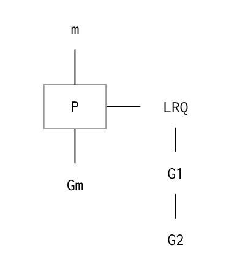

117-1

프로세서 `P`에 `m`을 위한 `Gm`이 실행하고, 2개의 `G1`과 `G2` 고루틴을 생성한다. 이것은 협조적 스케줄러(cooperating scheduler)이기에, 고루틴은 비선점적으로 스케줄링되고 운영체제 스레드인 `m`은 문맥교환(context switch)이 생기는 것을 의미한다.

스케줄러가 스케줄링을 하게 되는 4가지 상황이 있다.[재방문]

- `go` 키워드를 통해 고루틴들을 생성할 때. 이는 여러개의 프로세서(P)를 가지고 있을 때, 스케줄러가 균형을 다시 맞출 수 있다.
- 시스템 콜. 시스템 콜은 이미 항상 발생 하는 경향이 있다.
- 뮤텍스(Mutex)를 사용하는 채널. (추후 학습)
- 가비지 컬렉션.

다시 예제로 돌아와, 스케줄러는 `Gm`이 실행되기까지 충분한 시간이 남았을때, `Gm`을 실행 대기열(run queue)에 넣고 `G1`이 해당 `m`에서 실행되도록 혀용한다(문맥교환).

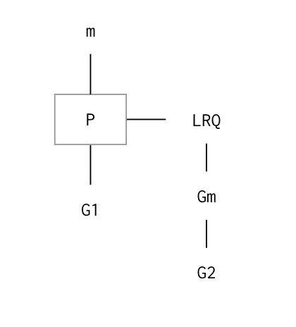

117-2

고루틴 `G1`에서 파일을 연다고 해보자. 파일을 여는 작업에 걸리는 시간이 얼마나 소요될지는 알 수 없다. 만약 파일을 열 때 이 고루틴(`G1`)이 OS 스레드를 블록(block) 시킨다면, 더 이상의 다른 작업을 완료할 수가 없다. 이 예제는 하나의 프로세서(`P`)와 싱글 스레드(`m`)로 동작하는 어플리케이션이다. 모든 고루틴은 프로세서(`P`)에 할당된 스레드(`m`)에서만 동작한다. 만약 고루틴이 프로세서(`P`)에 할당된 스레드(`m`)을 오랫동안 블록(block)시킨다면 어떻게 될까? 작업이 완료될 때까지 아무것도 할 수 없다. 이런일이 발생하지 않도록 하기 위해 스케줄러는 `m`과 `G1`을 분리한다. 새로운 `m`인 `m2`를 가져오고, 실행 대기열(run queue)에서 다음에 실행할 `G`, 즉 `G2`를 결정한다.

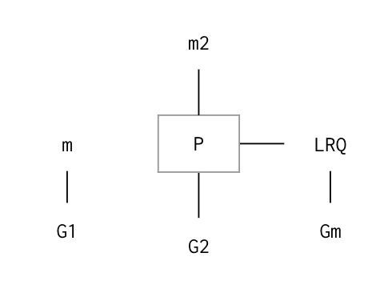

118-1

이제 싱글 스레드로 작성된 프로그램에 2개의 스레드가 있다. 우리의 관점에서 여전히 싱글 스레드 인데, 모든 고루틴과 관련된 코드는 프로세서(`P`)와 OS 스레드(`m`)에 대해서만 실행할 수 있기 때문이다. 하지만 어떤 `m`이 처리되고 있는지 알 수는 없다. 스레드(`M`)은 교체될 수 있고, 여전히 싱글 스레드로 이다.

`G1`이 파일 열기 작업을 끝냈을 때, 스케줄러는 `G1`을 실행 대기열(run queue)에 넣고나서 특정 스레드, 예제에서는 `m2`를 다시 실행할 수 있다. `m`은 다시 사용하기 위해 남겨지고, 여전히 2개의 스레드를 유지하고 있다. 전체 과정은 다시 일어날 수 있다.

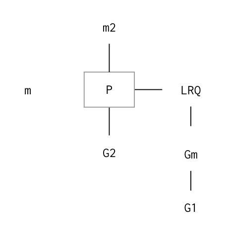

119-1

이렇듯 하나의 스레드 상에서 더 많은 작업을 수행함으로써, 해당 스레드로부터 최대의 가용성을 끌어 낼 수 있는 훌륭한 방법이다. 따라서 추가적인 스레드없이도 충분한 작업을 할 수 있다.

네트워크 폴러가 있고, 모든 로우 레벨(low level)의 비동기 네트워킹 작업을 수행한다. 고루틴은 이러한 작업을 수행할 경우, 네트워크 풀러로 이동한 다음 다시 대기열 뒤로 가져온다. 명심할 것은 작성된 코드는 프로세서(`P`)에 대응한 스레드(`m`)에서 실행된다는 것이다. 얼마나 많은 쓰레드를 실행하는 지는 프로세서(`P`)를 얼마나 가지고 있는지에 달려있다.

동시성이란 이런 많은 작업들을 한번에 관리할 수 있는 것을 의미하고, 이것이 스케줄러의 역할이다. 하나의 OS 스레드(`m`)에 의해 3개의 고루틴은 오직 한번에 하나의 고루틴만 실행될 수 있기 때문에, 하나의 프로세서(`P`), 하나의 스레드(`m`) 그리고 3개의 고루틴 실행을 관리한다. 만약 한번에 많은 일들을 동시에 처리하고 싶다면, 다시 말해서 병렬(parallel)처리하고 싶다면 또 다른 스레드(`m3`)를 처리할 수 있는 프로세서(`P`)가 하나 더 필요하다.

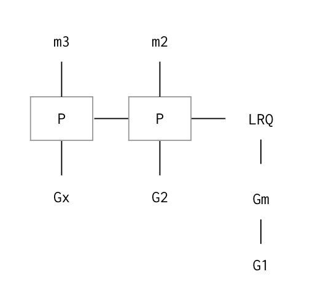

119-2

멀티 프로세서는 OS에 의해 스케줄링 된다. 이제 2개의 고루틴을 병렬(parallel)로 처리할 수 있다.

2개의 스레드로 실행되는 다중 스레드 소프트웨어를 가정해보자. 이제 2개의 고루틴을 병렬(parallel)로 처리할 수 있다. 프로그램은 2개의 스레드를 실행하고, 두 스레드가 동일한 코어에 있는 경우에도 서로에게 메세지를 전달하려고 한다. OS의 관점에서는 어떤 일이 일어나는지 알아보자.

먼저 첫번째 스레드가 스케줄링 되고 특정 코어에 할당될 때까지 기다려야 한다(문맥교환 발생). 이때, 아직 스레드는 대기 상태이므로 어떤 것도 실행 상태가 아니다. 첫번째 스레드에서 메세지를 보내고, 이에 대한 응답을 받기를 기다린다. 응답을 받기 위해서, 해당 코어에 다른 스레드를 배치할 수 있고 이를 통해서 또 다른 문맥교환이 발생한다. OS가 두번째 스레드를 스케줄링하기를 기다리며 또 다른 문맥교환이 발생한다. 대기 상태의 스레드를 깨우고 실행시켜 메세지를 처리한다. 메세지 전달 과정을 통해, 스레드는 실행 가능 상태(excutable state)에서 실행 대기 상태(runnable state)로 전환되며 대기 상태(asleep state) 순으로 바뀐다. 이러한 문맥교환들은 많은 비용(cost)이 발생한다

단일 코어에서 고루틴을 사용하면 어떤지 살펴보자. `G1`은 `G2`에게 메세지를 보내려 하고 문맥 교환이 일어난다. 하지만 이 문맥(`context`)은 사용자의 공간 전환이다. 스레드에서 실행 중인 `G1`을 `G2`로 전환할 수 있다. OS의 관점에서 이 스레드는 `sleep` 상태가 되지 않는다. 이 스레드는 항상 실행중이며, 문맥교환을 할 필요가 없다. Go 스케줄러는 고루틴을 계속해서 문맥교환 시켜준다.

프로세서(`P`)에 할당된 특정 스레드(`m`)가 처리할 고루틴(`G`)이 없다면, 런타임 스케줄러는 해당 스레드 코어 속에서 일정 시간 유효(`hot status`)할 수 있도록 스핀(`spin`) 상태로 만들어준다. 왜냐하면, 스레드가 더 이상 유효하지 않은 상태(`cold status`)라면 OS는 해당 스레드를 코어에서 빼내고 다른 스레드로 교체하기 때문이다. 따라서 비어 있는 스레드에 할당되어 처리할 고루틴(`G`)이 있을지 확인하기 위해, 잠시 스핀(`spin`) 상태가 되는 것이다.

이것이 스케줄러가 작동하는 방식이다. 프로세서(`P`)와 스레드(`m`)이 있고, OS는 스케줄링 작업을 할 것이다. 코어의 갯수보다 더 많은 것을 필요로 하지 않는데, 코어의 갯수보다 더 많은 OS 스레드가 필요하지 않다. 코어의 갯수보다 더 많은 스레드가 있다는 것은 OS에 적재하는 방법 뿐인데, Go의 스케줄러는 고루틴에 대해 최소한으로 필요한 스레드 수를 유지하고 작업을 계속해서 수행할 수 있도록 한다. Go의 스케줄러는 비선점적인 스케줄링으로 호출되더라도 선점된 것처럼 보인다.

하지만 개발을 쉽게 하기 위해서 스케줄링의 작동에 대해 잊고, 모든 고루틴(`G`)에 대해 `runnable state`에 있는 고루틴들은 모두 동시에 실행이 가능하다고 이해하자.

### Language Mechanics [재방문: 다른 번역자분들과 의견 맞추기, 의견: 언어 구조학]

소프트웨어가 깔끔하게 시작, 종료되도록 코드를 작성하는 것은 매우 중요하다.

```go
package main

import (
    "fmt"
    "runtime"
    "sync"
)
```

‘init’ 함수는 런타임 패키지에서 `GOMAXPROCS`을 호출한다. 환경 변수이기 때문에 대문자로 표기된다.

Go 1.5 이전에서는 코어 수의 관계 없이 하나의 프로세서(`P`)만 제공 되었다. 가비지 콜렉터와 스케줄러의 개선으로 모든것이 개선되었다.

스케줄러에게 하나의 논리 프로세서만 할당할 것을 명시한다.

```go
func init() {
    runtime.GOMAXPROCS(1)
}

func main() {
```

`wg`는 동시성을 관리하는데 사용된다. `wg`는 제로값으로 설정된다. 또한 제로값 상태에서 사용할 수 있는 Go의 매우 특별한 타입이다. 그리고 비동기 계산 세마포어(Asynchronous Counting Semaphore)로 불린다.

세개의 `Add`, `Done`, `Wait` 메소드를 갖는다. n개의 고루틴은 이 메소드를 동시에 호출 할 수 있고, 모두 직렬화(serialized)되어 있다.

- `Add`: 얼마나 많은 고루틴이 있는지 계산한다.
- `Done`: 일부 고루틴이 종료될 예정이므로 값을 감소시킨다.
- `Wait`: 해당 카운트가 0이 될 때까지 프로그램을 유지한다.

```go
    var wg sync.WaitGroup
```

2개의 고루틴을 생성하자. 반대로 Add(1)을 호출하고, 1씩 증가하기 위해 반복한다. 만약 얼마나 많은 고루틴이 생성될지 모른다면, 그것은 코드 스멜(smell)이다.

```go
    wg.Add(2)

    fmt.Println("Start Goroutines")
```

```go
    go func() {
        lowercase()
        wg.Done()
    }()
```

`lowercase` 이후에 고루틴을 하나 더 생성한다. 따라서, 이제는 3개의 고루틴이 동시에 실행된다.

```go
go func() {
    uppercase()
    wg.Done()
}()
```

고루틴이 끝날때까지 기다려보자. 메인이 종료되는 것을 대기(holding)시키는데, 메인이 종료될 때, 우리의 프로그램은 종료되고, 다른 고루틴을 신경쓰지 않기 때문이다.

여기서 중요한 것은 언제, 어떻게 고루틴이 종료되는지 모른다면 고루틴을 만들 수도 없다는 것이다. `Wait`는 두 개의 고루틴이 `Done`이 될때까지 대기(hold)하도록 한다. `2`에서 `0`이 될 때까지 카운트하고, `0`에 도달했을 때, 스케줄러는 메인 고루틴을 마저 실행하고, 종료 될 수 있도록 한다.

```go
    fmt.Println("Waiting To Finish") wg.Wait()
    wg.Wait()

    fmt.Println("\nTerminating Program")
}
```

`lowercase` 함수는 알파벳 소문자를 세번 반복 출력한다.

```go
func lowercase() {
    for count := 0; count < 3; count++ {
        for r := 'a'; r <= 'z'; r++ {
            fmt.Printf("%c ", r)
        }
    }
}
```

`uppercase` 함수는 알파벳 대문자를 세번 반복 출력한다.

```go
func uppercase() {
    for count := 0; count < 3; count++ {
        for r := 'A'; r <= 'Z'; r++ {
            fmt.Printf("%c ", r)
        }
    }
}
```

```
Start Goroutines
Waiting To Finish
A B C D E F G H I J K L M N O P Q R S T U V W X Y Z A B C D E F G H I J
K L M N O P Q R S T U V W X Y Z A B C D E F G H I J K L M N O P Q R S T
U V W X Y Z a b c d e f g h i j k l m n o p q r s t u v w x y z a b c d
e f g h i j k l m n o p q r s t u v w x y z a b c d e f g h i j k l m n
o p q r s t u v w x y z
Terminating Program
```

#### 순서

대기를 위해 `Wait`하지 않으면 어떻게 될까?

`uppercase` 함수와 `lowercase` 함수의 결과를 볼 수 없다. Go 스케줄러가 프로그램 종료를 막고 새로운 고루틴을 만들어 작업을 할당하기 전에 프로그램이 종료되는 일종의 경쟁으로 보인다. 기다리지 않기 때문에 고루틴은 실행할 기회가 전혀 없다.

`Done`을 호출하지 않으면 어떻게 될까?

교착상태(Deadlock)가 발생한다. Go의 특별한 부분이며, 런타임에서 고루틴이 존재하지만 더 이상 진행할 수 없을 때 패닉(panic)상태가 된다.

#### 고루틴 시분할(time slicing)

Go의 스케줄러는 선점 스케줄러(preemptive)가 아닌 협력 스케줄러(cooperating scheduler)에도 선점된 것처럼 생각되는 이유는 런타임 스케줄러가 프로그래머에게 인식되기 전에 모든 처리를 하기 때문이다.

아래의 코드는 문맥교환을 보여주고, 언제 문맥교환이 발생하는지 예상할 수 있도록 보여준다. 위 코드와 같은 패턴이지만 `printPrime` 함수가 새로 추가된다.

```go
package main

import (
    "fmt"
    "runtime"
    "sync"
)
```

하나의 논리 프로세서를 스케줄러에게 할당한다.

```go
func init() {
    runtime.GOMAXPROCS(1)
}
```

`wg`는 동시성을 관리하기 위해 사용한다.

```go
func main() {
    var wg sync.WaitGroup
    wg.Add(2)

    fmt.Println("Create Goroutines")
```

첫번째 고루틴을 생성하고, 생명주기를 관리한다.

```go
    go func() {
        printPrime("A")
        wg.Done()
    }()
```

두번째 고루틴을 생성하고, 생명주기를 관리한다.

```go
    go func() {
        printPrime("B")
        wg.Done()
    }()
```

고루틴이 종료될 때까지 대기한다.

```go
    fmt.Println("Waiting To Finish")
    wg.Wait()

    fmt.Println("Terminating Program")
}
```

`printPrime` 함수는 5000보다 작은 소수를 출력한다. 특별한 함수는 아니지만, 완료하기 위해 약간의 시간이 필요하다. 프로그램을 실행하면 특정 소수에서 문맥교환이 일어나는 것을 볼 수 있다. 하지만 문맥교환이 언제 일어날 지는 예측할 수 없기에 Go의 스케줄러가 협력 스케줄러임에도 불구하고 선점 스케줄러처럼 보인다고 말하는 이유이다.

```go
func printPrime(prefix string) {
next:
    for outer := 2; outer < 5000; outer++ {
        for inner := 2; inner < outer; inner++ {
            if outer%inner == 0 {
                continue next
            }
        }

        fmt.Printf("%s:%d\n", prefix, outer)
    }

    fmt.Println("Completed", prefix)
}
```

```
Create Goroutines
Waiting To Finish
B:2
B:3
B:5
B:7
B:11
B:13
B:17
B:19
...
B:4999
Completed B
A:2
A:3
A:5
A:7
A:11
A:13
A:17
A:19
...
A:4999
Completed A
Terminating Program
```

#### 고루틴과 병렬

이 프로그램은 고루틴이 병렬처리 되는 것을 보여준다. 2개의 프로세서(`P`), 2개의 스레드(`m`) 그리고 2개의 고루틴이 각각의 스레드(`m`)에서 병렬 처리 된다. 이전 프로그램과 비슷하지만 `lowercase` 함수와 `uppercase` 함수를 없애고, 익명 함수로 처리한다.

```go
package main
import (
    "fmt"
    "runtime"
    "sync"
)

func init() {
```

스케줄러에게 2개의 논리 프로세서를 할당한다.

```go
    runtime.GOMAXPROCS(2)
}

func main() {
```

`wg`는 프로그램이 종료될때까지 기다리는데 사용한다. `Add`에 2를 추가함으로, 2개의 고루틴이 종료될 때까지 대기한다.

```go
    var wg sync.WaitGroup
    wg.Add(2)

    fmt.Println("Start Goroutines")
```

소문자 알파벳을 3번 출력하는 익명 함수를 선언하고, 고루틴을 생성한다.

```go
    go func() {
        for count := 0; count < 3; count++ {
            for r := 'a'; r <= 'z'; r++ {
                fmt.Printf("%c ", r)
            }
        }
        wg.Done() //메인(main)에게 작업이 끝났음을 알린다.
    }
```

대문자 알파벳을 3번 출력하는 익명 함수를 선언하고, 고루틴을 생성한다.

```go
    go func() {
        for count := 0; count < 3; count++ {
            for r := 'A'; r <= 'Z'; r++ {
                fmt.Printf("%c ", r)
            }
        }
        wg.Done() //메인(main)에게 작업이 끝났음을 알린다.
    }()
```

고루틴이 끝나기를 기다린다.

```go
    fmt.Println("Waiting To Finish")
    wg.Wait()

    fmt.Println("\nTerminating Program")
}
```

소문자와 대문자가 섞여서 출력되는 것을 확인할 수 있다.

```
Start Goroutines
Waiting To Finish
a b c d e f g h i j k l m n o p q r s t u v w x y z a b c d e f g h i j
k l m n o p A B C D E F G H I J K L M N O P Q R S q r s t u v w x y z a
b c d e f g h i j k l m n o p q r s t u v w x y z T U V W X Y Z A B C D
E F G H I J K L M N O P Q R S T U V W X Y Z A B C D E F G H I J K L M N
O P Q R S T U V W X Y Z
Terminating Program
```

# 자원 경쟁(Data race)

## 경쟁 감지(Race Detection)

프로그램에 고루틴을 추가하면 복잡도가 엄청나게 올라간다. 고루틴을 언제나 상태없이(stateless) 실행할 수는 없기에 조율이 필요하다. 멀티 스레드 소프트웨어를 작성할 때는 사실상 두 가지 선택지가 있다.

- WaitGroup에서 Add와 Done, Wait으로 제어하는 것 처럼, 공유 자원에 대한 접근 상태를 동기화하거나
- 고루틴을 예측 가능하고, 합리적으로 실행이 되도록 만들어야 한다.

채널이 없었을 때는, 아토믹 함수나 mutex를 사용하여 앞서 언급한 두 가지 선택지를 구현하였다. 채널은 간단한 제어 방법을 제공하지만, 대부분의 경우는 아토믹 함수와 mutex를 사용하여 공유 자원에 대한 액세스 동기화를 사용하는 것이 가장 좋은 방법이다. atomic 연산은 Go에서 가장 빠른 방법이다. Go는 메모리에서 한번에 4-8 바이트씩 동기화를 하기 때문이다.

Mutex는 다음으로 빠르다. 채널은 매우 느린데, mutex일 뿐만 아니라 모든 데이터 구조와 로직이 함께 있기 때문이다. 여러개의 고루틴이 같은 자원에 접근하려할 때 자원 경쟁이 발생한다. 예를 들어, 2개의 고루틴이 int 타입의 counter라는 변수에 같은 시각에 접근하길 원하는 상황을 가정해 본다. 만약 실제로 같은 시간에 접근한다면 읽고 쓰기 위해 상호배제 할 것이다. 그렇기 때문에 공유하는 자원에 대해서 이런 접근이 필요할 때는 조정이 필요하다.

진짜 문제는 이러한 자원 경쟁이 항상 예상치 못하게 나타난다는 것이다. 예시 프로그램을 통해, 우리가 원하지 않는 자원 경쟁 상태를 만들어서 확인한다.

```go
package main

import (
    "fmt"
    "runtime"
    "sync"
)
```

`counter`는 모든 고루틴에 의해 증가되는 변수이다.

```go
var counter int

func main() {
```

사용할 고루틴의 수.

```go
    const grs = 2
```

`wg`는 동시성을 관리하는데 사용된다.

```go
    var wg sync.WaitGroup
    wg.Add(grs)
```

2개의 고루틴을 만들어준다.

두번 반복: local `counter`에 읽기를 수행하고 1 씩 증가한 다음 공유 상태에 다시 쓴다. 프로그램을 실행할 때마다 출력은 4가되어야한다. 여기서 발생하는 자원 경쟁: 주어진 시간동안 두개의 고루틴은 동시에 읽고, 쓸 수 있다. 그러나 우리는 운이 좋게도 각각의 고루틴이 3번의 실행을 모두 atomic하게 실행하고있다는 것을 볼 수 있다.

만약 `runtime.Goshed()`라는 줄을 추가하게되면, 다른 고루틴에게 CPU를 양보하게된다. 이때, 공유 자원을 읽게되면, 강제로 context switch가 일어나게되고, 자원 경쟁이 발생할 수 있다. 그렇게 되면 다시 돌아왔을 때 4라는 결과값을 얻지 못할수도 있다.

```go
    for i := 0; i < grs; i++ {
        go func() {
            for count := 0; count < 2; count++ {
```

이 때의 `counter` 값을 저장해 둔다.

```go
                value := counter
```

다른 고루틴에게 스레드를 양보하고, 다시 대기열에 들어간다.

FOR TESTING ONLY! DO NOT USE IN PRODUCTION CODE!

```go
                runtime.Gosched()
```

`counter`의 값을 늘린다.

```go
                value++
```

값을 `counter`에 다시 저장한다.

```go
                counter = value
            }
            wg.Done()
        }()
    }
```

고루틴이 끝날 때까지 기다린다.

```go
    wg.Wait()
    fmt.Println("Final Counter:", counter)
}
```

To identify race condition : go run -race .

```
==================
WARNING: DATA RACE
Read at 0x000001228340 by goroutine 8:
main.main.func1()

/Users/hoanhan/work/hoanhan101/ultimate-go/go/concurrency/data_race_1.go :65 +0x47
Previous write at 0x000001228340 by goroutine 7: main.main.func1()
/Users/hoanhan/work/hoanhan101/ultimate-go/go/concurrency/data_race_1.go

:75 +0x68
Goroutine 8 (running) created at: main.main()
/Users/hoanhan/work/hoanhan101/ultimate-go/go/concurrency/data_race_1.go :62 +0xab
Goroutine 7 (finished) created at: main.main()
/Users/hoanhan/work/hoanhan101/ultimate-go/go/concurrency/data_race_1.go :62 +0xab
==================
Final Counter: 4
Found 1 data race(s)
exit status 66
```

## 아토믹 함수(Atomic Functions)

```go
package main

import (
    "fmt"
    "runtime"
    "sync"
    "sync/atomic"
)
```

`counter`는 모든 고루틴에 의해 증가되는 변수이다. 해당 변수가 `int`가 아닌 `int64` 타입이라는 것에 유의해야한다. 아토믹 함수의 경우 정확성을 요구하기 때문에 구체적인 타입을 명시해야한다.

```go
var counter int64

func main() {
```

`grs`에 사용할 고루틴의 수를 지정.

```go
    const grs = 2
```

`wg`는 동시성을 관리하는데 사용된다.

```go
    var wg sync.WaitGroup
    wg.Add(grs)
```

2개의 고루틴들을 생성한다.

```go
    for i := 0; i < grs; i++ {
        go func() {
            for count := 0; count < 2; count++ {
```

`counter`에 동시성에 안전하게 1을 더해준다. 동기화 보장을 원하는 대상의 주소를 첫 번째 매개변수로 하는 원지적 연산 함수를 사용한다. 같은 주소에 대해 이러한 함수들을 사용하면, 이것들은 직렬화된다. 이것이 직렬화 할 수 있는 가장 빠른 방법이다.

우리는 이 프로그램을 하루 종일 실행하더라도 매번 4라는 값을 얻을 수 있다.

```go
                atomic.AddInt64(&counter, 1)
```

이 호출은 `AddInt64` 함수 호출이 완료됐을 때 `counter`가 이미 증가했으므로 큰 의미가 없다.

```go
                runtime.Gosched()
            }
        wg.Done()
        }()
    }
```

고루틴이 끝날 때까지 기다린다.

```go
    wg.Wait()
```

최종 값을 보여준다.

```go
    fmt.Println("Final Counter:", counter)
}
```

```
Final Counter: 4
```

## 뮤텍스(Mutexes)

일반적으로 데이터 공유를 하기 위해 매번 4-8바이트를 할당할 만큼 메모리가 여유롭지 않다. 이럴 때 뮤텍스를 사용하면 좋다. 뮤텍스를 사용하면 모든 고루틴이 한번에 하나씩 실행할 수 있는 WaitGroup(Add, Done and Wait)과 같은 API를 사용할 수 있다.

```go
package main

import (
    "fmt"
    "sync"
)

var (
```

`counter`는 모든 고루틴들에 의해 증가되는 변수이다.

```go
    counter int
```

`mutex`는 코드의 임계 구역을 정의하는데 사용된다. 모든 고루틴들이 통과해야하는 방으로 mutex를 상상해보자. 그러나 한번에 하나의 고루틴만이 이동할 수 있다. 스케줄러는 누가 들어갈지, 그리고 누가 다음이될지를 정한다. 우리는 스케줄러가 무엇을 할 지 결정할 수 없다. 바라건대, 그것은 공정할 것이다. 한 고루틴이 다른 고루틴들보다 먼저 문에 도착했다고해서 먼저 끝난다는 것을 의미하지는 않는다. 여기는 예측할 수 있는것이 없다.

여기서 핵심은 들어오도록 허용된 고루틴이, 나갈 때 보고해야 한다는 것이다. 모든 고루틴들은 다른 고루틴이 들어오도록 나갈때, 잠금과 해제를 요청한다. 두 개의 다른 함수가 동일한 `mutex`를 사용할 수 있으므로 한번에 하나의 고루틴만 주어진 함수를 실행할 수 있다.

```go
    mutex sync.Mutex
)
```

```go
func main() {
```

`grs`에 사용할 고루틴의 수를 지정.

```go
    const grs = 2
```

`wg`는 동시성을 관리하는데 사용된다.

```go
    var wg sync.WaitGroup
    wg.Add(grs)
```

2개의 고루틴들을 생성한다.

```go
    for i := 0; i < grs; i++ {
        go func() {
            for count := 0; count < 2; count++ {
```

Only allow one Goroutine through this critical section at a time. Creating these artificial curly brackets gives readability. We don’t have to do this but it is highly recommended. The Lock and Unlock function must always be together in line of sight. 한번에 오직 하나의 고루틴만이 임계 구역에 들어올 수 있도록 허용된다. 이렇게 중괄호를 만들어주면 가독성이 높아진다. 이 작업을 꼭 할 필요는 없지만 적극적으로 권장한다.. 잠금과 해제 함수는 항상 같은 맥락에 있도록 해야한다.

```go
                mutex.Lock()
                {
```

`counter`의 값을 저장한다.

```go
                    value := counter
```

`counter`의 로컬 값을 늘린다.

```go
                    value++
```

값을 다시 `counter`에 저장해준다.

```go
                    counter = value
                }
                mutex.Unlock()
```

잠금을 해제하고, 대기중인 고루틴들이 들어올 수 있도록 허용한다.

```go
            }

            wg.Done()
        }()
    }
```

고루틴이 끝날 때까지 기다린다.

```go
    wg.Wait()
    fmt.Printf("Final Counter: %d\n", counter)
}
```

```
Final Counter: 4
```

## 읽기/쓰기 뮤텍스(Read/Write Mutex)

많은 고루틴이 읽기 원하는 공유 자원이 있다고 하자.

때때로, 하나의 고루틴이 들어와서 리소스를 바꿀 수 있다. 그렇게 되면, 모두 읽는 것을 중단해야한다. 아무런 이유 없이 소프트웨어에 대기시간을 추가하기 때문에 이러한 유형의 사나리오에서 읽기를 동기화하는 것은 의미가 없다.

```go
package main

import (
    "fmt"
    "math/rand"
    "sync"
    "sync/atomic"
    "time"
)
```

`data`는 공유될 slice 이다.

```go
var (
    data []string
```

`rwMutex`는 코드의 임계 구역을 정의하는데 사용된다. 그것은 뮤텍스보다 살짝 느리지만 먼저 정확성을 최적화하고 있으므로 지금은 신경쓰지 않는다.

```go
    rwMutex sync.RWMutex
```

조회하는 시간에 시도된 읽기 수를 의미한다. 여기서 `int64`를 보자마자 아토믹 명령어 사용에 대해 생각해야한다.

```go
    readCount int64
)
```

`init`은 `main`보다 먼저 호출된다.

```go
func init() {
    rand.Seed(time.Now().UnixNano())
}

func main() {
```

`wg`는 동시성을 관리하는데 사용된다.

```go
    var wg sync.WaitGroup
    wg.Add(1)
```

10개의 서로 다른 쓰기를 수행하는 쓰기용 고루틴을 만든다.

```go
    go func() {
        for i := 0; i < 10; i++ {
            time.Sleep(time.Duration(rand.Intn(100)) * time.Millisecond)
            writer(i)
        }
        wg.Done()
    }()
```

영원히 실행되는 8개의 읽기용 고루틴을 만든다.

```go
    for i := 0; i < 8; i ++ {
        go func(i int) {
            for {
                reader(i)
            }
        }(i)
    }
```

쓰기 고루틴이 끝날 때까지 기다린다.

```go
    wg.Wait()
    fmt.Println("Program Complete")
}
```

쓰기용 고루틴은 임의의 간격으로 슬라이스에 새 문자열을 추가한다.

```go
func writer(i int) {
```

한번에 오직 하나의 고루틴만이 슬라이스에 읽기/쓰기를 하도록 허용된다.

```go
    rwMutex.Lock()
    {
```

현재 `readCount`를 캡쳐한다. 이 호출 없이 수행할 수 있지만 안전하게 처리하는 것이 좋다. 다른 고루틴이 읽기를 수행하지 않는 것을 보장해야 한다. 이 코드가 실행될 때 `rc`의 값은 항상 0 이어야한다.

```go
        rc := atomic.LoadInt64(&readCount)
```

전체 잠금이 있으므로 작업을 수행한다.

```go
        fmt.Printf("****> : Performing Write : RCount[%d]\n", rc)
        data = append(data, fmt.Sprintf("String: %d", i))
    }
    rwMutex.Unlock()
}
```

`reader`가 수행되고 데이터 슬라이스를 반복한다.

```go
func reader(id int) {
```

모든 고루틴은 쓰기 작업이 일어나지 않을 때 읽을 수 있다. `RLock`에는 그에 해당하는 `RUnlock`이 있다.

```go
    rwMutex.RLock()
    {
```

`readCount`를 1씩 증가시킨다.

```go
        rc := atomic.AddInt64(&readCount, 1)
```

읽기 작업을 수행하고 값을 표시한다.

```go
        time.Sleep(time.Duration(rand.Intn(10)) * time.Millisecond)
        fmt.Printf("%d : Performing Read : Length[%d] RCount[%d]\n", id, len(data), rc)
```

`readCount`를 1씩 감소시킨다.

```go
        atomic.AddInt64(&readCount, -1)
    }
    rwMutex.RUnlock()
}
```

출력은 이와 유사하게 잠긴다.

```
0 : Performing Read : Length[0] RCount[1]
4 : Performing Read : Length[0] RCount[5]
5 : Performing Read : Length[0] RCount[6]
7 : Performing Read : Length[0] RCount[7]
3 : Performing Read : Length[0] RCount[4]
6 : Performing Read : Length[0] RCount[8]
4 : Performing Read : Length[0] RCount[8]
1 : Performing Read : Length[0] RCount[2]
2 : Performing Read : Length[0] RCount[3]
5 : Performing Read : Length[0] RCount[8]
0 : Performing Read : Length[0] RCount[8]
7 : Performing Read : Length[0] RCount[8]
7 : Performing Read : Length[0] RCount[8]
2 : Performing Read : Length[0] RCount[8]
...
1 : Performing Read : Length[10] RCount[8]
5 : Performing Read : Length[10] RCount[8]
3 : Performing Read : Length[10] RCount[8]
4 : Performing Read : Length[10] RCount[8]
6 : Performing Read : Length[10] RCount[8]
7 : Performing Read : Length[10] RCount[8]
2 : Performing Read : Length[10] RCount[8]
2 : Performing Read : Length[10] RCount[8]
```

**Lesson:**

아토믹 함수와 뮤텍스는 사용자의 소프트웨어에 대기시간을 만든다. 대기시간은 여러 고루틴 사이에 자원 접근에 대한 조율이 필요할 때 유용하다. Read/Write 뮤텍스는 대기시간을 줄이는 데 유용하다.

뮤텍스를 사용하는 경우, 잠금 이후 최대한 빨리 잠금을 해제해야 한다. 다른 불필요한 행위는 하지 않는 것이 좋다. 때로는 공유 자원을 읽기를 위해 로컬 변수만 사용하는 것으로도 충분하다. 뮤텍스를 적게 사용할수록 좋다. 이를 통해 대기시간을 최소한으로 줄일 수 있다.

# 채널

## 언어 작동 원리

채널은 오케스트레이션(orchestration)을 위해 존재한다. 채널을 쓰면 2개의 고루틴(Goroutine)이 특정 워크플로우를 함께 처리하도록 할 수 있으며 또한 우리가 원하는 대로 워크플로우를 관리할 수 있다. 채널이 큐(queue)처럼 선입선출(first-in-first-out)로 구현된 듯 하지만 우리가 생각해야 하는 점은 채널이 큐라는 것이 아니다. 채널을 큐라고 생각하면 개념을 이해하기 어려워진다. 대신에 채널은 또다른 고루틴에 이벤트(event)가 발생했다는 신호를 주는 방식이라고 생각해야 한다. 멋지게도, 데이터가 있을 때는 물론 데이터 없이도 이벤트 신호를 줄 수 있다.

우리가 무슨 일을 하든 신호 주기(signaling)를 염두에 둔다면 채널을 적절한 방식으로 쓸 수 있다. 고(Go)에는 두 종류의 채널이 있다. 버퍼 없는(unbuffered) 채널과 버퍼 있는(buffered) 채널이다. 두 종류 중 어떤 것을 쓰든 신호를 주며 데이터를 보낼 수 있다. 중요한 차이점은 버퍼 없는 채널을 쓰면 신호를 줄 때 그 신호가 전달되었다는 보장을 받을 수 있다는 점이다. 고루틴이 우리가 할당한 작업을 끝냈는지 아닌지에 대해서는 알 수 없지만 적어도 그 보장은 받을 수 있다. 대신 신호가 전달되었다는 보장을 받는 대가로 더 긴 지연 시간(latency)을 감수해야 한다. 왜냐하면 버퍼 없는 채널의 반대편에 있는 고루틴이 데이터를 받았다는 것을 확실히 하기 위해 그 시점까지 기다려야 하기 때문이다.

버퍼 없는 채널이 작동하는 방식은 다음과 같다. 채널에 신호를 주려는 고루틴이 있다고 해보자. 채널은 신호와 함께 데이터도 보내려고 한다. 고루틴은 채널에 바로 데이터를 넣을 것이다. 하지만 채널은 반대편에 신호를 받을 고루틴이 있는지 알아야 하기 때문에 그때까지 데이터는 잠기고(locked) 움직일 수 없게 된다. 두 고루틴 모두 채널에 관여하고 있지 않고 있다. 마침내 고루틴이 와서 데이터를 받겠다고 말할 때, 데이터를 전송할 수 있다.

여기에 버퍼 없는 채널이 신호가 전달되었다는 보장을 해줄 수 있는 이유가 있다. 신호 받기가 먼저 일어난다. 신호 받기가 일어나면 신호가 전달되었다는 것을 알 수 있고, 이제야 다른 일을 하러 갈 수 있다.

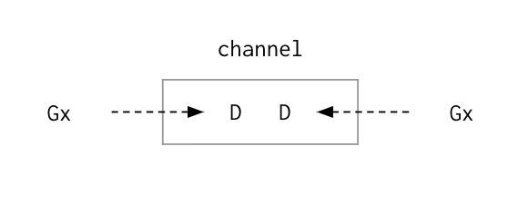

버퍼 없는 채널은 매우 강력한 채널이다. 이 보장을 최대한 활용하면 좋다. 하지만 다시 한번 말하건대 보장의 대가는 기다림 때문에 일어나는 긴 지연 시간이다.

버퍼 있는 채널은 약간 다르다. 우리는 신호가 전달되었다는 보장을 얻지 못하는 반면 신호 주기와 받기 모두에서 지연 시간을 줄일 수 있다.

앞의 예시로 되돌아가보자. 버퍼 없는 채널을 버퍼 있는 채널로 바꿨다고 해보자. 버퍼가 1밖에 안되는 채널을 쓴다고 가정할 것이다. 이는 채널 안에 1개의 데이터 조각을 위한 공간이 있다는 뜻이며 반대편이 데이터를 받을 때까지 기다릴 필요가 없다는 뜻이다. 따라서 이제 어떤 고루틴이 와서 데이터를 채널에 넣고 바로 가버릴 수 있다. 다시 말하면 신호 보내기가 신호 받기보다 먼저 일어난다. 고루틴이 신호 주기에 대해 아는 전부는 신호를 보냈고, 데이터를 넣었다는 것 뿐이며 신호가 언제 전달될지에 대해서는 아는 것이 없다. 이제 다른 고루틴이 와서 데이터가 있는 것을 보고 그걸 받아 가기를 바랄 뿐이다.

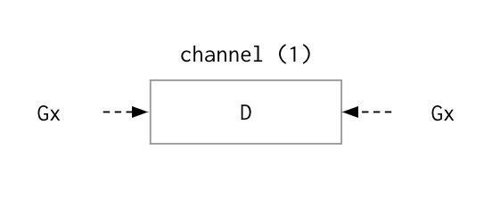

버퍼가 1개 있는 채널은 이런 종류의 지연 시간을 다룰 때 쓴다. 더 큰 버퍼가 필요할 때도 있지만 1개 이상의 버퍼를 쓸 때 적용되는 설계 규칙을 나중에 배우게 될 것이다. 하지만 신호 주기가 들어오고 있고 그 신호들이 잠길(locked) 가능성이 있는 상황이라면 우리는 다시 생각해봐야 한다. 버퍼 1개 채널이 우리가 맞닥뜨린 지연 시간을 줄이는 데 충분한가? 왜냐하면 앞으로 우리는 신호를 보낼 때마다 버퍼 있는 채널이 항상 비어있기를 바랄 것이기 때문이다.

버퍼 있는 채널은 성능을 위한 것이 아니다. 버퍼 있는 채널은 연속성을 위해, 바퀴가 계속 굴러가게 하기 위해 써야 한다. 우리가 알아두어야 할 것 중 하나는 모든 것이 문제 없이 동작할 때 잘 돌아가는 코드를 짜는 것은 아무나 할 수 있다는 점이다. 문제들이 생겨날 때가 바로 아키텍쳐와 엔지니어가 정말 중요해지는 시점이다. 우리가 만든 소프트웨어는 스트레스를 받지 않는다.[재방문] 스트레스를 받는 것은 우리다. 우리가 책임감을 가져야 한다.

예시로 돌아와서, 보낸 신호가 전달되었는지 정확히 아는 것이 중요하지는 않지만 신호가 확실히 전달되도록 해야 할 필요는 있다. 1개짜리 버퍼를 가진 채널은 거의 확실한 보장을 해준다. 왜냐하면 신호 보내기를 하고, 데이터를 집어넣고, 돌아섰다가, 다시 돌아왔을 때에 버퍼가 비워져 있는 것을 보기 때문이다. 이제 우리는 신호가 전달되었다는 것을 알 수 있다. 신호를 보냈을 시점에 즉시 알 수는 없지만 1개 짜리 버퍼를 씀으로써 돌아왔을 때 버퍼가 비어있다는 것은 알 수 있다.

그러고 나면 또다른 데이터 조각을 채널에 넣을 수 있다. 그리고 운이 좋다면 다시 돌아왔을 때 그 데이터는 사라져 있을 것이다. 만약 사라져 있지 않다면 문제다. 데이터를 받는 쪽에서 문제가 생긴 것이다.[재방문] 채널이 비워지기 전까지는 앞으로 나아갈 수 없다. 데이터가 왜 계속 머물러 있는지 알아야 하기 때문에 이런 문제는 즉시 보고해야 한다. 이것이 안정적인 시스템을 짓는 방법이다.

더 많은 일을 가져오지 말아야 한다.[재방문] 문제가 생겼을 때 데이터를 받는 쪽을 조사해야 하므로 시스템에 더 많은 부하를 주어서는 안된다. 우리가 책임질 수 없는 일에 더 많은 책임을 지어서는 안된다.

## 버퍼 없는 채널: 데이터를 담아 신호 주기

```go
package main

import (
    "fmt"
    "time"
)

func main() {
    fmt.Printf("\n=> Basics of a send and receive\n")
    basicSendRecv()

    fmt.Printf("\n=> Close a channel to signal an event\n")
    signalClose()
}
```

basicSendRecv는 신호 주기오 받기의 기본을 보여준다. make 함수는 채널을 만들 때 쓴다. make를 쓰지 않고서는 유용한 채널을 만드는 다른 방법은 없다. 채널은 우리가 신호에 담아 보낼 데이터의 타입에 기반한다. 이 경우에는 string을 썼다. 이 채널은 참조(reference) 타입이다. ch는 단지 수면 아래 있는 거대한 데이터 구조를 가리키는 포인터 변수이다.

```go
func basicSendRecv() {
```

아래는 버퍼 없는 채널이다.

```go
    ch := make(chan string)

    go func() {
```

아래는 신호 보내기다. 신호 주기는 이항 연산자(binary operation)이며 채널 쪽을 가리키는 화살표 기호를 사용한다. 여기서는 “hello”라는 string 변수로 신호를 주고 있다. This is a send: a binary operation with the arrow pointing into the channel. We are signaling with a string “hello”.

```go
        ch <- "hello"
    }()
```

아래는 신호 받기다. 신호 받기 역시 화살표지만 채널 왼쪽에 붙어 있으며 단항 연산자다. 이는 데이터가 채널에서 나오고 있다는 것을 보여준다. 이제 우리는 신호 보내기와 받기가 함께 있어야 하는 버퍼가 없는 채널을 갖고 있다. 또한 신호 받기가 먼저 일어나기 때문에 우리는 신호가 전달되었다는 것을 알 수 있다. 신호 보내기와 받기 모두 둘 모두가 모여서 전달이 일어날 수 있기 전까지는 멈출(block) 것이다.

```go
    fmt.Println(<-ch)
}
```

signalClose는 이벤트를 신호로 주기 위해 채널을 닫는(close) 법을 보여준다.

```go
func signalClose() {
```

여기서는 빈 구조체(struct)를 써서 채널을 만든다. 이는 데이터가 없는 신호이다.

```go
    ch := make(chan struct{})
```

이제 작업을 하기 위해 고루틴을 시작해보자. 고루틴이 100 밀리초(millisecond)가 걸린다고 가정해보자. 고루틴이 일을 마쳤을 때 또다른 고루틴에게 신호를 주려고 한다. 일이 끝났다는 것을 데이터가 없이 알리기 위해 채널을 닫을 것이다. 버퍼가 있든 없든 채널을 만들 때 채널은 두 상태(state) 중 하나에 놓일 수 있다. 모든 채널은 열린(open) 상태에서 시작해서 우리는 데이터를 주고 받을 수 있다. 채널을 닫힌(closed) 상태로 변경하면 다시 열릴 수 없다. 또한 채널을 두번 닫을 수도 없다. 정합성(integrity) 문제 때문이다. 데이터를 두번 보내지 않고는 신호를 두번 보낼 수 없다.

```go
    go func() {
        time.Sleep(100 * time.Millisecond)
        fmt.Println("signal event")
        close(ch)
}()
```

채널이 닫히면 신호를 받는 쪽은 즉시 반환(return)된다. 열려 있는 채널에서 신호를 받으려고 하면 데이터 신호를 받기 전까지 반환될 수 없다. 하지만 닫혀 있는 채널에서 신호를 받는다면 데이터 없이도 신호를 받을 수 있다. 우리는 이벤트가 일어났다는 것을 안다. 그 채널에 일어나는 모든 신호 받기는 즉시 반환될 것이다.

```go
    <-ch

    fmt.Println("event received")

}
```

```
=> Basics of a send and receive
hello

=> Close a channel to signal an event
signal event
event received
```

## 버퍼 없는 채널: 이중 신호

```go
package main

import (
    "fmt"
    "math/rand"
    "time"
)

func main() {
    fmt.Printf("\n=> Double signal\n")
    signalAck()

    fmt.Printf("\n=> Select and receive\n")
    selectRecv()

    fmt.Printf("\n=> Select and send\n")
    selectSend()

    fmt.Printf("\n=> Select and drop\n")
    selectDrop()
}
```

signalAck은 어떻게 이벤트를 신호로 줄 수 있고 처리가 끝났다는 승인(acknowledgement)을 기다릴 수 있는지 보여준다. 이는 신호가 전달되었다는 보장을 해줄 뿐만 아니라 작업이 끝난 때를 알 수 있다. 이는 이중 신호와 비슷하다.

```go
func signalAck() {
    ch := make(chan string)

    go func() {
        fmt.Println(<-ch)
        ch <- "ok done"
    }()
```

이 고루틴은 신호가 전달되기 전까지 멈춘(block)다. 즉 우리가 신호를 받기 전까지 이 고루틴은 움질일 수 없다.

```go
    ch <- "do this"
    fmt.Println(<-ch)
}
```

```
=> Double signal
do this
ok done
```

## 버퍼 없는 채널: 고르기와 받기

신호 고르기는 고루틴이 신호 보내기와 받기를 할 때 한번에 여러 채널을 다루는 방식이다. 이 방식은 이벤트 루프(event loop)를 만들 때 매우 쓸모 있지만 공유 상태(shared state)를 직렬화(serializing)하는 데는 별로 좋지 않다. selectRecv는 고르기(select) 문을 써서 값(value)을 받을 때까지 특정 시간만큼을 기다리는 방식을 보여준다.

```go
func selectRecv() {
    ch := make(chan string)
```

특정 시간만큼을 기다리고 신호 보내기를 수행한다.

```go
    go func() {
        time.Sleep(time.Duration(rand.Intn(200)) * time.Millisecond)
        ch <- "work"
    }()
```

2개의 서로 다른 채널에서 2개의 서로 다른 신호를 받는다. 한 채널은 위에서 본 것이고 다른 한 채널은 시간을 재기 위해서다. time.After는 주어진 만큼의 시간이 지난 뒤 현재 시간 신호를 보내는 채널을 돌려준다. 우리는 작업을 처리하면서 보내는 신호를 받고 싶지만 끝없이 기다릴 생각은 없다. 우리는 100 밀리초만 기다리고 그 뒤에는 다음으로 넘어갈 것이다.

```go
    select {
    case v := <-ch:
        fmt.Println(v)
    case <-time.After(100 * time.Millisecond):
        fmt.Println("timed out")
}
```

하지만 이 코드에는 매우 흔한 버그(bug)가 있다. 우리가 앞으로 보게 될 가장 커다란 버그 중 하나는 위와 같은 코드를 짜고 고루틴에게 종료될 기회를 주지 않을 때 생긴다. 버퍼 없는 채널을 쓰고 있는데 이 고루틴은 언젠가는 기다리는 시간이 끝나고 신호 보내기를 하고 싶을 것이다. 하지만 이것은 버퍼 없는 채널이다. 신호 보내기는 대응하는 신호 받기가 없으면 완료될 수 없다. 만약 고루틴이 시간 초과되고 그 다음으로 넘어간다면 어떻게 될까? 대응하는 신호 받기가 없으므로 고루틴 누수(leak)가 생길 것이다. 다시 말해 이 고루틴은 결코 종료되지 않을 것이다.

이 버그를 고치는 가장 깔끔한 방법은 1개짜리 버퍼가 있는 채널을 쓰는 것이다. 신호 보내기가 일어날 때 신호가 전달되리라는 보장을 할 수는 없다. 하지만 우리는 이 보장이 필요 없다. 단지 신호를 보낼 필요가 있을 뿐이며 보내고 나서는 다음으로 넘어갈 수 있다. 그러므로 반대쪽에서 신호를 받거나 아니면 못 받고 그냥 넘어갈 것ㅇ다. 신호를 받지 못하더라도 신호 보내기가 일어나도록 신호를 담을 자리가 버퍼에 있기 때문에 이 신호 보내기는 여전히 완료된다.

```go
=> Select and receive
work
```

## 버퍼 없는 채널: 고르기와 보내기

selectSend는 신호 보내기를 시도할 때 특정 시간 동안만 시도하기 위해 신호 고르기 문(select statement)을 어떻게 쓸 수 있는지를 보여준다.

```go
func selectSend() {
    ch := make(chan string)

    go func() {
        time.Sleep(time.Duration(rand.Intn(200)) * time.Millisecond)
        fmt.Println(<-ch)
    }()

    select {
    case ch <- "work":
        fmt.Println("send work")
    case <-time.After(100 * time.Millisecond):
        fmt.Println("timed out")
}
```

위 함수와 비슷하게 고루틴 누수는 일어날 것이다. 다시 한번, 1개짜리 버퍼 채널이 여기서 우리를 구해줄 것이다.

```
=> Select and send
work
send work
```

## 버퍼 있는 채널: 고르기와 버리기

selectDrop은 신호 고르기(select)를 써서 채널이 즉시 막혔을(block) 때 넘어가는 방식을 보여준다.

이는 매우 중요한 패턴이다. 서버에 할일이 들이닥쳤거나 할일이 곧 오는 상황을 상상해보자. 서버가 일을 맡길 모듈은 제대로 동작하고 있지 않다.[재방문] 그렇다고 일을 그냥 쌓아놓을 수도 없다. 이 때 우리는 앞으로 계속 나아가기 위해서 일을 버려야 한다.

서비스 거부 공격(Denial-of-service attack)은 좋은 예시이다. 우리는 서버로 오는 수많은 요청을 받는다. 우리가 요청 하나하나 모두 처리하려고 든다면 아마 서버는 터지고 말 것이다. 우리는 처리할 수 있는 것은 처리하고 다른 요청은 버려야 한다.

이런 종류의 패턴(fanout)을 써서 우리는 몇몇 데이터를 버리려고 한다. 이를 위해 1개보다 큰 버퍼를 쓸 수 있다. 버퍼가 얼마나 커야 할지는 재보아야 한다. 아무렇게나 정할 수는 없다.

```go
func selectDrop() {
    ch := make(chan int, 5)

    go func() {
```

여기서 우리는 신호 받기 루프(loop)에서 작업할 데이터가 오기를 기다리고 있다.

```go
        for v := range ch {
            fmt.Println("recv", v)
        }
    }()
```

아래 코드는 작업을 채널에 보낼 것이다. 버퍼가 다 차면, 버퍼는 막히게(block) 되고, 기본 케이스(default case)가 실행되며 작업을 버리게 된다.

```go
    for i := 0; i < 20; i++ {
        select {
        case ch <- i:
            fmt.Println("send work", i)
        default:
            fmt.Println("drop", i)
        }
    }

    close(ch)
}
```

```
=> Select and drop
send work 0
send work 1
send work 2
send work 3
send work 4
send work 5
drop 6
drop 7
drop 8
drop 9
drop 10
drop 11
drop 12
drop 13
drop 14
drop 15
recv 0
recv 1
recv 2
recv 3
recv 4
recv 5
drop 16
send work 17
send work 18
send work 19
```

## 버퍼 없는 채널 (테니스 경기)

아래 프로그램은 고루틴 2개를 테니스 매치에 넣을 것이다. 여기서는 공이 양쪽 편에서 쳐지거나 놓쳤다는 보장을 필요로 하기 때문에 버퍼 없는 채널을 쓴다.

```go
package main

import (
    "fmt"
    "math/rand"
    "sync"
    "time"
)

func init() {
    rand.Seed(time.Now().UnixNano())
}

func main() {
```

버퍼 없는 채널을 생성한다.

```go
    court := make(chan int)
```

wg는 동시성을 관리하기 위해 쓰인다.

```go
    var wg sync.WaitGroup
    wg.Add(2)
```

선수 둘을 입장시킨다. 둘 모두 받기 모드에서 시작할 것이다. 어떤 선수가 먼저 공을 받게 될지는 알 수 없다. 메인 고루틴을 심판이라고 생각하자. 누가 공을 먼저 받는지는 심판에게 달려 있다.

```go
    go func() {
        player("Hoanh", court)
        wg.Done()
    }()

    go func() {
        player("Andrew", court)
        wg.Done()
    }()
```

테니스 경기를 시작한다. 메인 고루틴이 신호 보내기를 한다. 선수 둘 모두 신호 받기 모드이므로 어느 쪽이 먼저 공을 받게 될지 알 수 없다.

```go
    court <- 1
```

경기가 끝날 때까지 기다린다.

```go
    wg.Wait()
}
```

player는 테니스 경기를 하는 사람을 흉내낸다. 값 의미(value semantic)를 써서 채널 값을 요구한다.[재방문]

```go
func player(name string, court chan int) {
    for {
```

공이 다시 넘어올 때까지 기다린다. 이게 또다른 형태의 신호 받기라는 점을 놓치지 말자. 단순히 값을 받는 대신에 신호 받기가 어떻게 반환되었는지 나타내는 플래그(flag)를 받을 수 있다. 만약 신호가 데이터 때문에 생겼다면 ok는 true일 것이다. 만약 신호가 데이터 없이 생겼다면, 다른 말로 채널이 닫혔다면 ok는 false일 것이다. 이를 통해 누가 이겼는지 결정할 수 있다.

```go
        ball, ok := <-court
        if !ok {
```

만약 채널이 닫혔다면 우리가 이긴 것이다.

```go
            fmt.Printf("Player %s Won\n", name)
            return
        }
```

무작위 값을 하나 정해서 공을 놓쳤는지 (즉, 우리가 졌는지) 알아본다. 만약 경기에서 진다면 채널을 닫을 것이다. 그러면 반대편 player는 데이터 없이 신호를 받았다는 것을 알게될 것이다. 채널은 닫히고 반대편 player가 이긴다. player 둘 모두 반환한다.[재방문]

```go
        n := rand.Intn(100)
        if n%13 == 0 {
            fmt.Printf("Player %s Missed\n", name)
```

우리가 졌다는 신호를 보내기 위해 채널을 닫는다.

```go
            close(court)
            return
        }
```

공을 친 횟수를 보여주고 하나 증가시킨다. 만약 위에서 말한 두가지 경우가 생기지 않는다면 경기는 아직 진행 중이다. 공의 값을 하나 증가시키고 신호 보내기를 한다. 반대편 player는 여전히 신호 받기 모드에 있다는 것을 우리는 안다. 그러므로 신호를 보내는 쪽과 받는 쪽은 결국 함께 모일 것이다. 다시 한번, 버퍼 없는 채널에서는 전달이 보장되기 때문에 신호 받기가 먼저 일어난다.

```go
        fmt.Printf("Player %s Hit %d\n", name, ball)
        ball++
```

공을 쳐서 상대 선수에게 다시 보낸다.

```go
        court <- ball
    }
}
```

```
Player Andrew Missed
Player Hoanh Won
```

## 버퍼 없는 채널 (이어 달리기)

이 프로그램은 고루틴 네 개 간의 이어 달리기를 흉내내기 위해 버퍼 없는 채널을 쓰는 방식을 보여준다. 달리기 선수 네 명이 트렉에 있다고 상상해보자. 한번에 한 명만 달릴 수 있으며 마지막 선수를 제외하고는 다음에 달릴 사람이 있다. 다음 선수는 앞 선수에 이어서 달릴 때까지 기다린다.

```go
package main

import (
    "fmt"
    "sync"
    "time"
)
```

wg는 프로그램이 끝나기까지 기다리기 위해 쓰인다. var wg sync.WaitGroup

```go
func main() {
```

버퍼 없는 채널을 생성한다.

```go
    track := make(chan int)
```

마지막 선수를 위해 값이 1인 횟수를 더한다.[재방문] 우리가 관심 있는 건 마지막 선수가 우리에게 끝났다고 알려주는 것뿐이기 때문에 1만 더한다.

```go
    wg.Add(1)
```

첫번째 선수를 출발선 상에 생성한다.[재방문]

```go
    go Runner(track)
```

메인 고루틴이 달리기를 시작한다. (신호총을 쏜다) 이 순간에 우리는 다른 쪽에서는 고루틴이 신호 받기를 하고 있다는 것을 알고 있다.

```go
    track <- 1
```

달리기가 끝나기를 기다린다.

```go
    wg.Wait()
}
```

Runner는 이어 달리기에서 달리는 사람을 흉내낸다. Runner는 처음부터 끝까지 모든 일을 하고 종료될 것이기 때문에 루프(loop)를 갖고 있지 않다. 우리는 이 패턴이 동작하게 하기 위해 고루틴 Runner를 계속 더할 것이다.

```go
func Runner(track chan int) {
```

바통이 넘겨진 횟수다.

```go
    const maxExchanges = 4

    var exchange int
```

데이터와 함께 바통을 받을 때까지 기다린다.

```go
    baton := <-track
```

트렉을 달리기 시작한다.

```go
    fmt.Printf("Runner %d Running With Baton\n", baton)
```

출발선에 있는 새로운 선수다. 이 선수가 달리기 마지막 선수인가? 아니라면 몇번째 선수인지 기록하기 위해 데이터에 1을 더한다. 우리는 고루틴을 하나 더 만들 것이다. 새로운 고루틴은 즉시 신호 받기 모드에 돌입할 것이다. 이제 트렉에 두번째 고루틴이 있으며 바통을 받기를 기다리고 있다. (1)

```go
    if baton < maxExchanges {
        exchange = baton + 1
        fmt.Printf("Runner %d To The Line\n", exchange)
        go Runner(track)
    }
```

트렉을 한바퀴 돈다.

```go
    time.Sleep(100 * time.Millisecond)
```

경기가 끝났는가.

```go
    if baton == maxExchanges {
        fmt.Printf("Runner %d Finished, Race Over\n", baton)
        wg.Done()
        return
    }
```

다음 선수에게 바통을 넘겨준다.

```go
    fmt.Printf("Runner %d Exchange With Runner %d\n", baton, exchange)
```

마지막 선수가 아니기 때문에 (1)이 받을 수 있도록 신호 보내기를 한다.

```go
    track <- exchange
}
```

```
Runner 1 Running With Baton
Runner 2 To The Line
Runner 1 Exchange With Runner 2
Runner 2 Running With Baton
Runner 3 To The Line
Runner 2 Exchange With Runner 3
Runner 3 Running With Baton
Runner 4 To The Line
Runner 3 Exchange With Runner 4
Runner 4 Running With Baton
Runner 4 Finished, Race Over
```

## 버퍼 있는 채널: 팬 아웃

다음은 1개보다 큰 버퍼가 있는 채널의 고전적인 사용 예시이다. 팬 아웃(Fan Out) 패턴이라고 불린다.

아이디어는 다음과 같다. 고루틴이 할일을 하다가 많은 데이터베이스 작업을 실행하기로 결정했다고 해보자. 이 고루틴은 그 일을 하기 위해 새로운 고루틴을 여러개, 예컨대 10개를 만들어낼 것이다. 각 고루틴은 데이터베이스 작업 2개를 수행할 것이다. 결국 데이터베이스 작업 20개가 고루틴 10개로 쪼개진다. 다시 말하면 원래 있던 고루틴이 고루틴 10개를 팬 아웃(fan out)하고 생성한 모든 고루틴이 작업을 끝내고 보고하기를 기다리는 것이다.

여기서는 버퍼 있는 채널이 딱인데 이는 우리가 미리 20개 작업을 수행하는 고루틴이 10개 있을 것이라는 점을 알기 때문이다. 따라서 버퍼 크기는 20이다. 우리는 결국 마지막에는 작업 신호를 받아야 한다는 점을 알기 때문에 어떤 작업 신호도 막힐 염려가 없다.

```go
package main

import (
    "fmt"
    "log"
    "math/rand"
    "time"
)
```

result는 각 연산이 끝나고 돌려받는 것이다.

```go
type result struct {
    id  int
    op  string
    err error
}

func init() {
    rand.Seed(time.Now().UnixNano())
}

func main() {
```

고루틴 수와 연산 수를 설정한다.

```go
    const routines = 10
    const inserts = routines * 2
```

어떤 입력에 대해서든 정보를 받기 위해 버퍼 있는 채널을 연다.

```go
    ch := make(chan result, inserts)
```

우리가 처리해야 할 응답의 개수이다. 이 고루틴은 자신의 스택 공간(stack space)를 관리할 수 있기 때문에 WaitGroup을 쓰는 대신 지역 변수(local variable)을 WaitGroup처럼 쓸 것이다. 그러므로 시작하자마자 이 지역 변수를 입력 20개로 설정한다.

```go
    waitInserts := inserts
```

모든 입력을 수행한다. 이것이 바로 팬 아웃이다. 이제 우리에게는 고루틴이 10개 있다. 각 고루틴은 입력 두 개를 수행한다. 입력의 결과는 ch 채널에서 쓰인다. 이 채널은 버퍼 있는 채널이기 때문에 어떤 신호 보내기도 막히지(blcok) 않는다.

```go
    for i := 0; i < routines; i++ {
        go func(id int) {
            ch <- insertUser(id)
```

버퍼 있는 채널을 쓴 덕에 두번째 입력을 시작하기 위해 기다릴 필요가 없다. 첫번째 신호 보내기는 즉시 끝난다.

```go
            ch <- insertTrans(id)
        }(i)
    }
```

입력이 끝나면 입력 결과를 처리한다.

```go
    for waitInserts > 0 {
```

고루틴에서 오는 응답을 기다린다. 이건 신호 받기다. 한번에 결과 하나씩을 받고 waitInserts을 0이 될 때까지 줄일 것이다.

```go
        r := <-ch
```

결과를 보여준다.

```go
        log.Printf("N: %d ID: %d OP: %s ERR: %v", waitInserts, r.id, r.op, r.err)
```

waitInserts를 줄이고 일이 끝났는지 확인한다.

```go
        waitInserts--
    }
    log.Println("Inserts Complete")
}
```

insertUser는 데이터베이스 작업을 흉내낸다.

```go
func insertUser(id int) result {
    r := result{
        id: id,
        op: fmt.Sprintf("insert USERS value (%d)", id),
}
```

입력이 실패했는지 아닌지 무작위로 결정한다.

```go
    if rand.Intn(10) == 0 {
        r.err = fmt.Errorf("Unable to insert %d into USER table", id)
    }
    return r
}
```

insertTrans도 데이터베이스 작업을 흉내낸다.

```go
func insertTrans(id int) result {
    r := result{
        id: id,
        op: fmt.Sprintf("insert TRANS value (%d)", id),
    }
```

입력이 실패했는지 아닌지 무작위로 결정한다.

```go
    if rand.Intn(10) == 0 {
        r.err = fmt.Errorf("Unable to insert %d into USER table", id)
    }
    return r
}
```

```
2020/08/24 18:18:19 N: 20 ID: 0 OP: insert USERS value (0) ERR: <nil>
2020/08/24 18:18:19 N: 19 ID: 0 OP: insert TRANS value (0) ERR: <nil>
2020/08/24 18:18:19 N: 18 ID: 1 OP: insert USERS value (1) ERR: <nil>
2020/08/24 18:18:19 N: 17 ID: 1 OP: insert TRANS value (1) ERR: <nil>
2020/08/24 18:18:19 N: 16 ID: 2 OP: insert USERS value (2) ERR: <nil>
2020/08/24 18:18:19 N: 15 ID: 2 OP: insert TRANS value (2) ERR: Unable to insert 2 into USER table
2020/08/24 18:18:19 N: 14 ID: 3 OP: insert USERS value (3) ERR: Unable to insert 3 into USER table
2020/08/24 18:18:19 N: 13 ID: 3 OP: insert TRANS value (3) ERR: <nil>
2020/08/24 18:18:19 N: 12 ID: 4 OP: insert USERS value (4) ERR: <nil>
2020/08/24 18:18:19 N: 11 ID: 4 OP: insert TRANS value (4) ERR: <nil>
2020/08/24 18:18:19 N: 10 ID: 5 OP: insert USERS value (5) ERR: <nil>
2020/08/24 18:18:19 N: 9 ID: 5 OP: insert TRANS value (5) ERR: <nil>
2020/08/24 18:18:19 N: 8 ID: 6 OP: insert USERS value (6) ERR: <nil>
2020/08/24 18:18:19 N: 7 ID: 6 OP: insert TRANS value (6) ERR: <nil>
2020/08/24 18:18:19 N: 6 ID: 7 OP: insert USERS value (7) ERR: <nil>
2020/08/24 18:18:19 N: 5 ID: 7 OP: insert TRANS value (7) ERR: Unable to insert 7 into USER table
2020/08/24 18:18:19 N: 4 ID: 8 OP: insert USERS value (8) ERR: <nil>
2020/08/24 18:18:19 N: 3 ID: 8 OP: insert TRANS value (8) ERR: <nil>
2020/08/24 18:18:19 N: 2 ID: 9 OP: insert USERS value (9) ERR: <nil>
2020/08/24 18:18:19 N: 1 ID: 9 OP: insert TRANS value (9) ERR: <nil>
2020/08/24 18:18:19 Inserts Complete
```

## 고르기

다음 예시 프로그램은 채널을 써서 프로그램이 도는 시간을 모니터링하고 너무 오래 돌면 종료시키는 방식을 보여준다.

```go
package main

import (
    "errors"
    "log"
    "os"
    "os/signal"
    "time"
)
```

프로그램이 일을 끝내기까지 3초의 시간을 주자.

```go
const timeoutSeconds = 3 * time.Second
```

우리는 채널 4개를 쓸 것이다. 버퍼 없는 채널 3개와 버퍼 있는 채널 1개를 쓴다.

```go
var (
```

sigChan은 운영 체제 신호를 받는다. 이 변수를 써서 프로그램을 깔끔하게 종료시키기 위해 Ctrl-C을 보낼 것이다.

```go
    sigChan = make(chan os.Signal, 1)
```

timeout은 프로그램이 돌 수 있는 시간을 제한한다. 이 채널에서 신호를 받는 일이 없었으면 좋겠다. 이 채널에서 신호를 받으면 뭔가 안 좋은 일이 생겼다는 뜻이고, 시간 초과가 일어나고, 프로그램을 종료시켜야 하기 때문이다.

```go
    timeout = time.After(timeoutSeconds)
```

complete는 처리가 끝났다는 것을 알리기 위해 쓴다. 이 채널이 우리가 신호를 받고 싶은 채널이다. 고루틴이 작업을 끝냈을 때 complete 채널을 통해 우리에게 신호를 줄 것이다. 어떤 에러가 일어났는지도 이 채널을 통해 알려줄 것이다.

```go
    complete = make(chan error)
```

shutdown은 시스템 전체 알림을 주기 위해 쓴다.

```go
    shutdown = make(chan struct{})
)

func main() {
    log.Println("Starting Process")
```

우리는 인터럽트(interrupt) 관련 신호를 전부 받으려고 한다. signal 패키지에 있는 Notify 함수를 쓰면서 sigChan을 파라미터로 넘겨줄 것이다. 이는 sigChan 채널에게 os.Interrupt와 관련 있는 어떤 신호든지 보이면 우리에게 데이터 신호를 보내라고 말하는 것이다. 이 API에서 중요한 점은 우리가 신호를 받을 준비가 되어 있을 때까지 기다리지 않는다는 점이다. 우리가 신호를 받지 못한다면 신호는 그냥 바닥에 버려질 것이다. 여기서 1개짜리 버퍼가 있는 채널을 쓰는 이유가 바로 이것이다. 이것이 적어도 신호 1개를 받는 것을 보장받는 방법이다. 이 신호에 맞추어 행동할 준비가 되어 있을 때 우리는 신호를 받고 행동할 것이다.

```go
    signal.Notify(sigChan, os.Interrupt)
```

프로세스를 시작한다.

```go
    log.Println("Launching Processors")
```

아래 고루틴이 예컨대 이미지 처리 같은 처리를 할 것이다.

```go
    go processor(complete)
```

여기 있는 메인 고루틴은 이벤트 루프 안에 있고 프로그램이 종료될 때까지 무한히 루프를 돌 것이다. 고르기(select)에는 세가지 케이스가 있는데 이는 우리가 신호를 받으려고 하는 채널이 동시에 3개 있다는 뜻이다. sigChan과 timeout, complete가 있다.

```go
ControlLoop:
    for {
        select {
        case <-sigChan:
```

운영 체제에서 보낸 인터럽트(interrupt) 이벤트 신호이다.

```go
            log.Println("OS INTERRUPT")
```

프로세서에게 종료하라는 신호를 보내기 위해 채널을 닫는다.

```go
            close(shutdown)
```

이런 이벤트를 더이상 처리하지 않기 위해 채널을 nil로 설정한다.

닫힌 채널에 신호를 계속 보내려고 하면 패닉(panic)이 일어날 것이다. 닫힌 채널에서 신호를 받으려고 하면 즉시 데이터 없는 신호를 돌려받는다. nil 채널에서 신호를 받으려고 하면 영원히 막힐(block) 것이다. 신호 보내기도 비슷하다. 이렇게 하는 이유가 뭘까?

우리는 유저가 Ctrl C를 누르고 있거나 Ctrl C을 여러번 누르기를 바라지 않는다. 만약 유저가 그렇게 한다면 우리는 그 신호를 처리하고 close를 여러번 호출해야 한다. 이미 닫힌 채널에 close를 호출하면 코드는 패닉한다. 그러므로, 이런 상황에 놓이지 않기 위해 채널을 nil로 설정한다.

```go
            sigChan = nil
        case <-timeout:
```

시간을 너무 많이 썼다. 어플리케이션을 종료시키자.

```go
            log.Println("Timeout - Killing Program")
            os.Exit will terminate the program immediately.
            os.Exit(1)
        case err := <-complete:
```

아래는 주어진 시간 내에 완료된 모든 것이다.

```go
            log.Printf("Task Completed: Error[%s]", err)
```

여기서 우리는 레이블(label) break를 쓴다. case가 break할 수 있고 for가 break할 수 있게 하기 위해 for 루프의 맨 위에 레이블을 놓는다.

```go
            break ControlLoop
        }
    }

    log.Println("Process Ended")
}
```

processor는 프로그램의 메인 로직을 담당한다. 이 파라미터에는 재밌는 부분이 있다. chan 키워드 오른쪽에 화살표가 있다. 이것은 채널이 신호 보내기 전용이라는 뜻이다. 이 채널에서 신호를 받으려고 하면 컴파일러는 에러를 뱉을 것이다.

```go
func processor(complete chan<- error) {
    log.Println("Processor - Starting")
```

어떤 에러가 일어나든 에러를 저장할 변수를 만든다. 클로저(closure)를 써서 defer 함수에 넘겨진다.

```go
    var err error
```

함수가 어떻게 끝났는지 상관없이 채널에 신호를 보내기 위해 신호 보내기를 지연(defer)시킨다. 이는 고루틴에서 보았던 것처럼 익명(anonymous) 함수 호출이다. 하지만 여기서 우리는 키워드 defer를 쓴다.

이 함수를 실행시키고 싶지만 processor가 끝난 후에 실행시키고 싶다. 이 방식은 함수를 호출한 쪽에 컨트롤이 넘어가기 전에 정해진 일이 확실히 일어난다는 보장을 해준다.

또한 defer는 패닉을 멈출 수 있는 유일한 방법이다. 안 좋은 일, 예컨대 이미지 라이브러리가 터지는 일이 생긴다면 코드 전체에 걸쳐 패닉 상황을 일으킬 것이다. 이 경우에 우리는 패닉에서 회복(recover)하고, 패닉을 멈추고, 종료를 컨트롤 하고 싶다.

```go
    defer func() {
```

어떤 패닉 상황이든 잡아낸다.

```go
        if r := recover(); r != nil {
            log.Println("Processor - Panic", r)
        }
```

고루틴에 종료해야 한다고 알려준다.

```go
        complete <- err
    }()
```

작업을 수행한다.

```go
    err = doWork()
    log.Println("Processor - Completed")
}
```

doWork는 작업을 흉내낸다. 모든 호출 사이에 우리는 checkShutdown을 호출한다. 모든 작업을 마친 후에는 다음 질문을 한다. “종료하라는 말을 들은 적이 있는가?” 이것을 아는 유일한 방법은 shutdown 채널이 닫혔는지 보는 것이다. shutdown 채널이 닫혔는지 아는 유일한 방법은 그 채널에서 신호 받기를 해보는 것이다. 닫히지 않은 채널에서 신호 받기를 하면 막힐(block) 것이다. 하지만 기본 케이스(default case)가 우리를 구해줄 것이다.

```go
func doWork() error {
    log.Println("Processor - Task 1")
    time.Sleep(2 * time.Second)

    if checkShutdown() {
        return errors.New("Early Shutdown")
    }

    log.Println("Processor - Task 2")
    time.Sleep(1 * time.Second)

    if checkShutdown() {
        return errors.New("Early Shutdown")
    }

    log.Println("Processor - Task 3")
    time.Sleep(1 * time.Second)

    return nil
}
```

checkShutdown은 종료 플래그를 확인해서 처리를 중단하도록 요청받은 적이 있는지 결정한다.

```go
func checkShutdown() bool {
    select {
    case <-shutdown:
```

여기서 우리는 깔끔하게 프로그램을 종료하도록 요청받았다.

```go
        log.Println("checkShutdown - Shutdown Early")
        return true

    default:
```

shutdown 채널이 닫히지 않았다면 정상적인 처리 중이라고 가정한다.

```go
        return false
    }
}
```

프로그램을 실행시킬 때 시간 제한을 3초로 설정했기 때문에 시간 초과가 일어나고 종료될 것이다.

```
2020/08/24 18:31:27 Starting Process
2020/08/24 18:31:27 Launching Processors
2020/08/24 18:31:27 Processor - Starting
2020/08/24 18:31:27 Processor - Task 1
2020/08/24 18:31:29 Processor - Task 2
2020/08/24 18:31:30 Timeout - Killing Program
exit status 1
```

프로그램이 돌고 있을 때 Ctrl C을 누르면 OS INTERRUPT라고 뜨고 프로그램은 일찍 종료한다.

```
2020/08/24 18:21:02 Starting Process
2020/08/24 18:21:02 Launching Processors
2020/08/24 18:21:02 Processor - Starting
2020/08/24 18:21:02 Processor - Task 1
^C2020/08/24 18:21:03 OS INTERRUPT
2020/08/24 18:21:04 checkShutdown - Shutdown Early
2020/08/24 18:21:04 Processor - Completed
2020/08/24 18:21:04 Task Completed: Error[Early Shutdown]
2020/08/24 18:21:04 Process Ended
```

Ctrt 눌러서 종료 신호를 보내면 모든 고루틴의 전체 스택 트레이스(stack trace)를 받을 수 있다.

```
2020/08/24 18:31:44 Starting Process
2020/08/24 18:31:44 Launching Processors
2020/08/24 18:31:44 Processor - Starting
2020/08/24 18:31:44 Processor - Task 1
2020/08/24 18:31:46 Processor - Task 2
^\SIGQUIT: quit
PC=0x7fff70c3e882 m=0 sigcode=0
goroutine 0 [idle]:
runtime.pthread_cond_wait(0x12201e8, 0x12201a8, 0x7ffe00000000)
        /usr/local/go/src/runtime/sys_darwin.go:378 +0x39
runtime.semasleep(0xffffffffffffffff, 0x7ffeefbff678)
        /usr/local/go/src/runtime/os_darwin.go:63 +0x85
runtime.notesleep(0x121ffa8)
        /usr/local/go/src/runtime/lock_sema.go:173 +0xe0
runtime.stoplockedm()
        /usr/local/go/src/runtime/proc.go:2068 +0x88
runtime.schedule()
        /usr/local/go/src/runtime/proc.go:2469 +0x485
runtime.park_m(0xc00007cd80)
        /usr/local/go/src/runtime/proc.go:2610 +0x9d
runtime.mcall(0x108ca06)
        /usr/local/go/src/runtime/asm_amd64.s:318 +0x5b

goroutine 1 [select]:
main.main()

/Users/hoanhan/work/hoanhan101/ultimate-go/go/concurrency/channel_6.go:6

7 +0x278

goroutine 19 [syscall]:
os/signal.signal_recv(0x108ebb1)
        /usr/local/go/src/runtime/sigqueue.go:144 +0x96
os/signal.loop()
        /usr/local/go/src/os/signal/signal_unix.go:23 +0x30
created by os/signal.init.0
        /usr/local/go/src/os/signal/signal_unix.go:29 +0x4f

goroutine 5 [sleep]:

runtime.goparkunlock(...)
        /usr/local/go/src/runtime/proc.go:310
time.Sleep(0x3b9aca00)
        /usr/local/go/src/runtime/time.go:105 +0x157
main.doWork(0xc000054768, 0x1)

/Users/hoanhan/work/hoanhan101/ultimate-go/go/concurrency/channel_6.go:157 +0x14a
main.processor(0xc000096060)

/Users/hoanhan/work/hoanhan101/ultimate-go/go/concurrency/channel_6.go:138 +0xbc
created by main.main

/Users/hoanhan/work/hoanhan101/ultimate-go/go/concurrency/channel_6.go:58 +0x160

rax 0x104
rbx 0x2
rcx 0x7ffeefbff498
rdx 0x200
rdi 0x12201e8
rsi 0x20100000300
rbp 0x7ffeefbff530
rsp 0x7ffeefbff498
r8 0x0
r9 0xa0
r10 0x0
r11 0x202
r12 0x12201e8
r13 0x16
r14 0x20100000300
r15 0x10863dc0
rip 0x7fff70c3e882
rflags 0x203
cs 0x7
fs 0x0
gs 0x0
exit status 2
```

# Patterns

## Context

### Store and retrieve values from a context

`context` 패키지는 취소(cancellation)와 데드라인(deadline)을 지원한다.

```go
package main

import (
    "context"
    "fmt"
)
```

`user` 는 context 내에 값을 저장하기 위한 타입이다.

```go
type user struct {
    name string
}
```

`userKey`는 `user`의 값에 대한 키(key) 타입이다. 키는 하나의 타입이고, 동일한 타입의 값만 매치할 수 있다. context 에 값을 저장하면, 그 값의 타입도 저장된다. 값을 추출하려면, context 안의 값의 타입을 알아야만 한다. `userKey` 타입과 같은 아이디어는 context에 값을 저장하는 경우, 생각보다 상당히 중요한 개념이다.

```go
type userKey int

func main()
```

`user` 타입의 값을 생성한다.

```go
    u := user {
        name: "Hoanh",
    }
```

키를 제로값으로 선언한다.

```go
    const uk userKey = 0
```

context에 `user` 값의 포인터 그리고 `userKey` 타입의 제로값을 저장하자. 새로운 `context` 값을 생성하기 위해서 `context.WithValue` 함수를 사용하며, 미리 준비한 데이터를 바탕으로 초기화를 하고자 한다. context를 가지고 작업을 할 때마다 context에는 상위 context(parent context)가 있어야 한다. 그래서, `Background` 함수를 도입한다. 키인 `uk`를 그 키의 값(여기서는 `0`에 해당함) 그리고 `user`의 주소(address)를 저장 할 것이다.

```go
    ctx := context.WithValue(context.Background(), uk, &u)
```

`user` 포인터 타입인 값을 추출해보자. `Value`는 특정한 타입의 값을 전달하면(이 경우 `userKey` 타입의 `uk`), 빈 인터페이스 타입을 반환한다.

인터페이스에 저장된 값을 꺼내려면 타입 단언(type assertion)을 해줘야 한다.

```go
    if u, ok := ctx.Value(uk).(*user); ok {
        fmt.Println("User", u.name)
    }
```

다른 타입을 가지고 위의 값을 검색해보려고 시도해 보자. 비록 키의 실제 값이 `0`이지만, 이 함수 호출에 `0`을 전달한다 해도 원하고자 하는 `user`의 주소를 얻을 수 없을 것이다. `0`은 정수 타입이지, 우리가 정의한 `userKey` 타입이 아니기 때문이다.

context에 값을 저장 할 떄, built-in 타입을 사용하지 않는 것이 중요하다.

사용자가 정의한 타입의 키를 사용하자. 그러면 이 타입을 알아야만 context에서 값을 꺼낼 수 있다. 만약, 여러 프로그램이 숫자 `0` 키값을 사용해 `user`를 추출한다면, 모든 것이 엉망이 되어버릴 수 있다. 사용자 정의 타입은 context에 값을 저장하고 추출할 때에 추가적인 보호를 해준다. 구체적인 타입을 사용하지 않으면 매 호출 시 왜 이런 식인지 계속 확인하게 만들기 때문에 잘못된 것을 알 수 있다. 따라서, 구체적인 타입을 사용하는 것이 향후 레거시 코드의 가독성과 유지관리에 훨씬 더 유리할 것이다.

```go
    if _, ok := ctx.Value(0).(*user); !ok {
        fmt.Println("User Not Found")
    }
```

```
User Hoanh
User Not Found
```

### WithCancel

Go에서는 취소(cancellation)와 타임아웃(timeout)을 다른 방법으로도 할 수 있다.

```go
package main

import (
    "context"
    "fmt"
    "fime"
)

func main() {
```

수동으로만 취소할 수 있는 context를 만들어 보자. `cancel` 함수는 결과와 상관없이 호출 해야 한다. `WithCancel`을 사용하면, context를 생성 할 수 있으며, 고루틴(goroutine)이 실행하는 모든 작업을 즉시 중단하기를 원하는 신호(데이터 없는 신호)를 전달하기 위해 호출 할 수 있는 `cancel` 함수를 제공한다. 다시 강조하지만, 여기서도 `Background`를 상위 context (parent context)로 사용하고 있다.

```go
    ctx, cancel := context.WithCancel(context.Background())
```

`cancel` 함수는 결과와 상관없이 반드시 호출해야 한다. context를 생성하는 고루틴은 항상 `cancel` 함수를 호출해야 한다. 이러한 것들은 깔끔하게 정리해 주어야 한다. (역주: `cancel` 함수를 반드시 호출할 수 있게 정리 해 주어야 함) 고루틴이 모든 작업이 완료된 이후, `cancel` 함수를 호출하도록 context를 생성하는 당시에 확인하는 것이 필요하다. `defer` 키워드는 위와 같은 사용사례(use case)에 적합하다.

```go
    defer cancel()
```

몇몇 작업을 수행하기 위해서 고루틴을 사용하고자 한다. 데이터 없이 50ms 정도 지연을 한 이후, `cancel` 함수를 호출하려 한다. 데이터 없이 `cancel` 신호를 보내고 싶다고 전달하고 있다.

```go
    go func() {
```

작업을 시뮬레이션 해 보자. 50ms 만큼의 시간을 사용하여 프로그램을 실행할 경우, 해당 작업이 완료될 것으로 예상 해 본다. 그러나 만약, 150ms 정도의 시간이 소요된다면, 계속 진행하고자 한다.

```go
        time.Sleep(50 * time.Millisecond)
```

작업이 종료됨을 보고하자.

```go
        cancel()
    }()
```

해당 채널을 만든 원래의 고루틴은 `select case` 구문에 있다. `time.After` 이후, 값을 전달받게 될 것이다. 100ms 동안 대기하거나 `context.Done`이 완료되기를 기다린다. 이렇게 계속 기다리다 `Done`을 받게 된다면, 해당 작업이 완료되었음을 알 수 있다.

```go
    select {
    case <-time.After(100 * time.Millisecond):
        fmt.Println("moving on")
    case <-ctx.Done():
        fmt.Println("work complete")
    }
}
```

```
work complete
```

### WithDeadline

```go
package main

import (
    "context"
    "fmt"
    "time"
)

type data struct {
    UserID string
}

func main() {
```

데드라인을 설정한다.

```go
    deadline := time.Now().Add(150 * time.Millisecond)
```

수동으로 취소 가능하거나 특정 날짜/시간에 취소 신호를 보낼 수 있는 컨텍스트를 생성한다. `Background`를 부모 컨텍스트로 사용하고 데드라인 시간을 설정한다.

```go
    ctx, cancel := context.WithDeadline(context.Background(), deadline)
    defer cancel()
```

작업 종료의 신호를 수신할 수 있는 채널을 생성한다.

```go
   ch := make(chan data, 1)
```

고루틴에 작업을 하도록 요청한다.

```go
    go func() {
```

작업을 시뮬레이션 한다.

```go
        time.Sleep(200 * time.Millisecond)
```

작업이 끝났음을 알려준다.

```go
        ch <- data{"123"}
    }()
```

작업이 끝나기를 기다린다. 만약 시간이 많이 걸릴 경우 취소를 이행한다.

```go
    select {
    case d := <-ch:
        fmt.Println("work complete", d)
    case <-ctx.Done():
        fmt.Println("work cancelled")

    }
}
```

```
work cancelled
```

### WithTimeout

```go
package main

import (
    "context"
    "fmt"
    "time"
)

type data struct {
    UserID string
}

func main (){
```

기간을 설정한다.

```go
    duration := 150 * time.Millisecond
```

수동으로 취소 가능하거나 특정 기간에 취소 신호를 보낼 수 있는 컨텍스트를 생성한다.

```go
    ctx, cancel := context.WithTimeout(context.Background(), duration)
    defer cancel()
```

작업 종료의 신호를 수신할 수 있는 채널을 생성한다.

```go
    ch := make(chan data, 1)
```

고루틴에 작업을 하도록 요청한다.

```go
    go func() {
```

작업을 시뮬레이션 한다.

```go
        time.Sleep(50 * time.Millisecond)
```

작업이 끝났음을 알려준다.

```go
        ch <- data{"123"}
    }()
```

작업이 끝나기를 기다린다. 만약 시간이 많이 걸릴 경우 취소를 이행한다.

```go
    select {
    case d := <-ch:
        fmt.Println("work complete", d)
    case <-ctx.Done():
        fmt.Println("work cancelled")
    }
}
```

```
work complete {123}
```

### Request/Response 171

리퀘스트가 너무 오래 걸리는 경우 타임아웃에 사용되는, 컨텍스트를 이용한 뤱 리퀘스트를 구현한 프로그램이다.

```go
package main

import (
    "context"
    "io"
    "log"
    "net"
    "net/http"
    "os"
    "time"
)

func main() {
```

새로운 리퀘스트를 생성한다.

```go
    req, err := http.NewRequest("GET", "https://www.ardanlabs.com/blog/post/index.xml", nil)
    if err != nil {
        log.Println(err)
        return
    }
```

제한시간이 50ms인 컨텍스트를 생성한다.

```go
    ctx, cancel := context.WithTimeout(req.Context(), 50 * time.Millisecond)
    defer cancel()
```

호출에 대한 새로운 Transport와 클라이언트를 선언한다.

```go
    tr := http.Transport {
        Proxy: http.ProxyFromEnvironment,
        DialContext: (&net.DialerP{
            Timeout:   30 * time.Second,
            Timeout:   30 * time.Second,
            DualStack: true,
        }).DialContext,
        MaxIdleConns:          100,
        IdleConnTimeout:       90 * time.Second,
        TLSHandshakeTimeout:   10 * time.Second,
        ExpectContinueTimeout: 1 * time.Second,
    }
    client := http.Client{
        Transport: &tr,
    }
```

취소 가능하도록 별도의 고루틴으로 웹 호출을 생성한다.

```go
    ch := make(chan error, 1)
    go func() {
        log.Println("Starting Request")
```

웹 호출을 수행하고 `error.Client.Do`에서 얻는 것을 리턴하고 리퀘스트 URL을 호출하려고 해본다. 전체 문서가 돌아올 때 까지 대기해야 하기 때문에 지금 당장은 블록될 것이다.

```go
        resp, err := client.Do(req)
```

오류가 발생하면, 채널에서 작업이 완료되었음을 보고한다. 어떤 시점에서 어떤 일이 일어났는지 보고하기 위해서 채널을 사용할 것이다.

```go
        if err != nil {
            ch <- err
            return
        }
```

실패하지 않는다면, 리턴할 때에 respose body를 닫는다.

```go
        defer resp.Body.Close()
```

`stdout`에 respose를 작성한다.

```go
        io.Copy(os.Stdout, resp.Body)
```

그리고, `error`대신에 `nil`을 돌려보낸다.

```go
        ch <- nil
    }()
```

리퀘스트 혹은 타임아웃을 기다린다. `ctx.Done()`에 대한 수신을 수행해서 위의 전체 프로세스가 일어날 때 까지 50ms을 기다린다. 그렇지 않은 경우, 리퀘스트 취소 신호를 고루틴으로 보낸다. 이것이 필요로 하지 않기 때문에, 자원을 소비하도록 내버려 둘 필요가 없다. `CancelRequest`를 호풀 할 수 있으며, 바로 아래에서 커넥션을 종료할 수 있다.

```go
    select {
    case <-ctx.Done():
        log.Println("timeout, cancel work...")
        tr.CancelRequest(req)
        log.Println(<-ch)
    case err := <-ch:
        if err != nil {
            log.Println(err)
        }
    }
}
```

```
2020/08/24 18:37:18 Starting Request
2020/08/24 18:37:18 timeout, cancel work...
2020/08/24 18:37:18 Get https://wwww.ardanlabs.com/blog/post/index.xml:
net/http: request canceled while waiting for connection
```